# U1-Predicting-response-times-of-the-Paris-Fire_Brigade-vehicles

##### 3.1.2.3 Group Together Categories With Low Frequency & Manage Outliers

for the floor variable, group everything below -2 & everything after 17

```r
table(data.clean$floor)
```

```
##
##    -10     -6     -5     -4     -3     -2     -1      0      1      2      3
##      1      5      5    113    141    612   3690 127043  17675  14697  12284
##      4      5      6      7      8      9     10     11     12     13     14
##   9758   6883   4704   2749   1689   1119    784    564    417    315    250
##     15     16     17     18     19     20     21     22     23     24     25
##    182    131    134     73     25     14     23     23     11     11      8
##     26     27     28     29     30     31     32     33     37     52     79
##     15     17      3     12     10      1      7      2      4      1      1
##    100
##      9
```

```r
levels(data.clean$floor)<-list("-2"=c("-10","-9","-6","-5","-4","-3", "-2"),"-1"=c("-1"),"0"=c("0"),"1"=c("1"),"2"=c("2"),"3"=c("3"),"4"=c("4"),"5"=c("5"),"6"=c("6"),"7"=c("7"),"8"=c("8"),"9"=c("9"),"10"=c("10"),"11"=c("11"),"12"=c("12"),"13"=c("13"),"14"=c("14"),"15"=c("15"),"16"=c("16"),"17"=c("17","18","19","20","21","22","23","24","25","26","27","28","29", "30", "31", "32", "33", "37","52","79","100"))


table(data.clean$floor)
```

```
##
##     -2     -1      0      1      2      3      4      5      6      7      8
##    877   3690 127043  17675  14697  12284   9758   6883   4704   2749   1689
##      9     10     11     12     13     14     15     16     17
##   1119    784    564    417    315    250    182    131    404
```

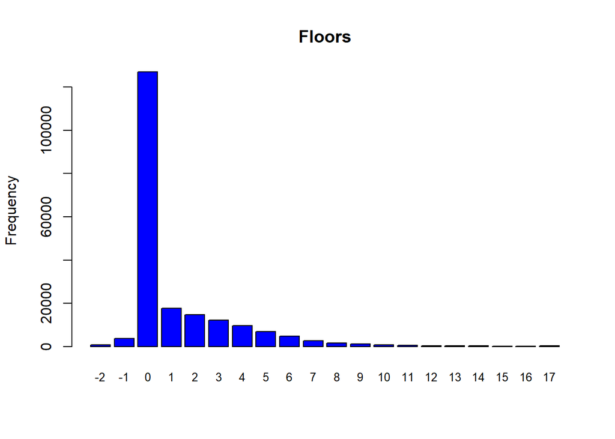

```r
barplot(table(data.clean$floor),horiz = F,cex.names=0.8,col="blue",main="Floors",ylab="Frequency", plot=TRUE)
```

```r
data.quali<-data.clean[,c(3,4,5,6,7,10,11,12,15,17)]
```

Apply same for x_test

```r
levels(x_test$floor)<-list("-2"=c("-10","-9","-6","-5","-4","-3", "-2"),"-1"=c("-1"),"0"=c("0"),"1"=c("1"),"2"=c("2"),"3"=c("3"),"4"=c("4"),"5"=c("5"),"6"=c("6"),"7"=c("7"),"8"=c("8"),"9"=c("9"),"10"=c("10"),"11"=c("11"),"12"=c("12"),"13"=c("13"),"14"=c("14"),"15"=c("15"),"16"=c("16"),"17"=c("17","18","19","20","21","22","23","24","25","26","27","28","29", "30", "31", "32", "33", "37","52","79","100"))
```

#### 3.1.2.4 Clean outliers for rescue.center

```r
table(data.quali$rescue.center)
```

```
##
##   2418   2434   2435   2436   2437   2438   2439   2440   2441   2442   2443
##     15   2324   1905   3472   3085   3071   3789   1318   4137   4213   3549
##   2444   2445   2446   2447   2448   2449   2450   2451   2452   2454   2455
##   3266   2846   4961   4816   3022   3703   3273   2507   2052   3120   2610
##   2456   2457   2458   2459   2460   2462   2463   2464   2465   2467   2469
##   2729   2485   2569   2025   4054   2625   4583   1842   2397   2748   4501
##   2470   2471   2472   2473   2474   2475   2476   2477   2478   2479   2480
##   2963   1075   2929   2257   4114   5591   1379   5628   3903   3197   3114
##   2481   2482   2483   2484   2485   2486   2487   2488   2489   2490   2491
##   2854   1413   2177   2787   2819   4463   1561   5114   2505   2183   3929
##   2492   2493   2494   2495   2496   2497   2498   2499   2500   2501   2503
##   2241   3134   1755   1232   1587   4438   1263   2584   2172   3031   1084
##   2505   2506   2507   2508   2509   2510 266281 266290 266294 266296 266321
##    617   2168   2866   1759   2614   2944      2   1148      2      1      2
## 266323 266324
##      3      1
```

We remove some levels (for data.clean$rescue.center variable) which are not significant for us because there are very few samples for them.

table(data.clean$rescue.center) levels(data.clean$rescue.center)

data.clean$rescue.center <- subset(data.clean$rescue.center, data.clean$rescue.center != “266281”)

data.clean <- data.clean[data.clean$rescue.center != 266281,]

data.clean <- data.clean[data.clean$rescue.center != 266294,]

data.clean <- data.clean[data.clean$rescue.center != 266296,]

data.clean <- data.clean[data.clean$rescue.center != 266321,]

data.clean <- data.clean[data.clean$rescue.center != 266323,]

data.clean <- data.clean[data.clean$rescue.center != 266324,]

table(droplevels(data.clean$rescue.center))

table(data.clean$rescue.center)

### 3.2. What is time difference between departure.presentation and OSRM estimated duration ?

Let’s compute time difference between departure.presentation(actual) and OSRM estimated duration (predicted). This difference can’t be taken into account in our future model.

```r
time.diff<-data.clean$delta.departure.presentation-data.clean$OSRM.estimated.duration
time.diff %>% head
```

```
## [1]   17.2  -99.2 -177.4   18.4 -131.6  -68.7
```

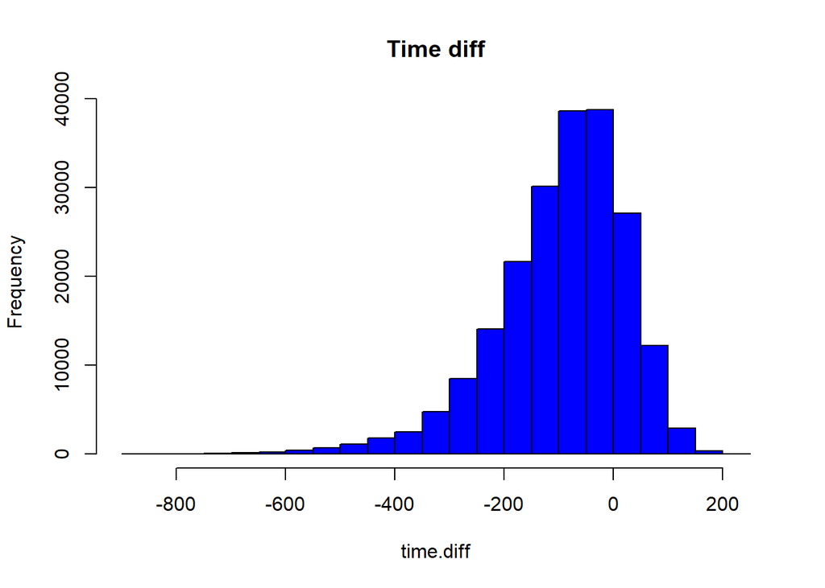

```r
hist(time.diff, col="blue",main="Time diff")
```

```r
summary(time.diff)
```

```
##    Min. 1st Qu.  Median    Mean 3rd Qu.    Max.
## -870.70 -159.40  -77.10  -95.38  -12.50  243.70
```

## 4. Feature engineering

### 4.1: Speed [km/h]

estimated speed by OSRM : distance / time

```r
data.fe<-data.clean
data.fe$OSRM.estimated.speed<-(data.clean$OSRM.estimated.distance/1000)/(data.clean$OSRM.estimated.duration/60^2)
data.fe$OSRM.estimated.speed %>% summary()
```

```
##    Min. 1st Qu.  Median    Mean 3rd Qu.    Max.
##   9.661  26.177  30.806  31.394  35.633  69.382
```

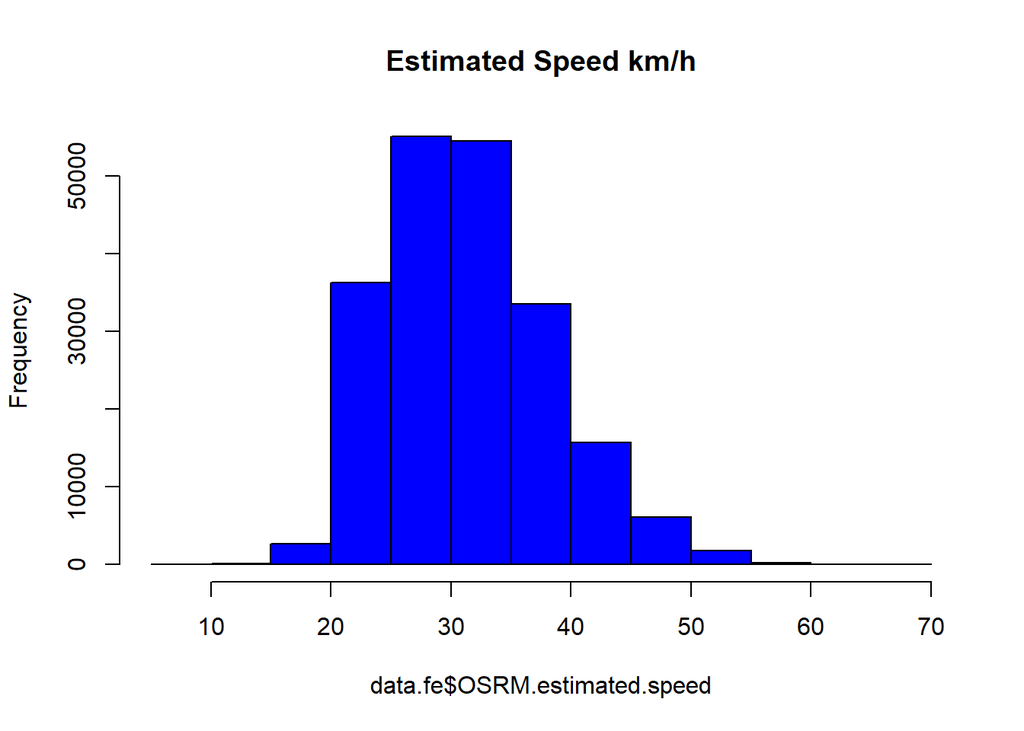

```r
hist(data.fe$OSRM.estimated.speed , col="blue",main="Estimated Speed km/h")
```

Same for x_test

```r
x_test$OSRM.estimated.speed<-(x_test$OSRM.estimated.distance/1000)/(x_test$OSRM.estimated.duration/60^2)
```

#### 4.1.2 How top influencer predictors and estimated speed correlate ?

```r
data.fe.sample <- sample_n(data.fe, 100)
```

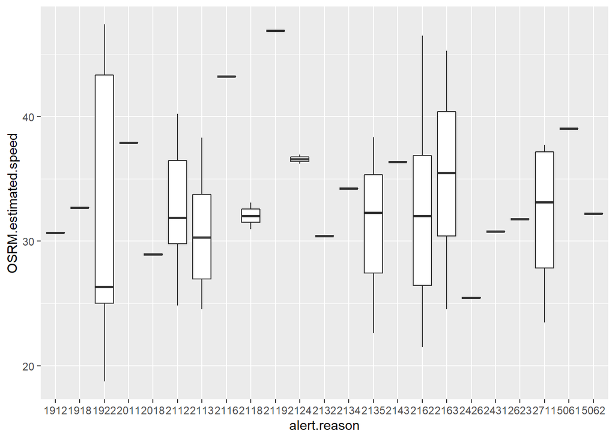

```r
data.fe.sample %>%
  ggplot(aes(x=alert.reason, y=OSRM.estimated.speed,group=alert.reason)) +
  geom_boxplot()
```

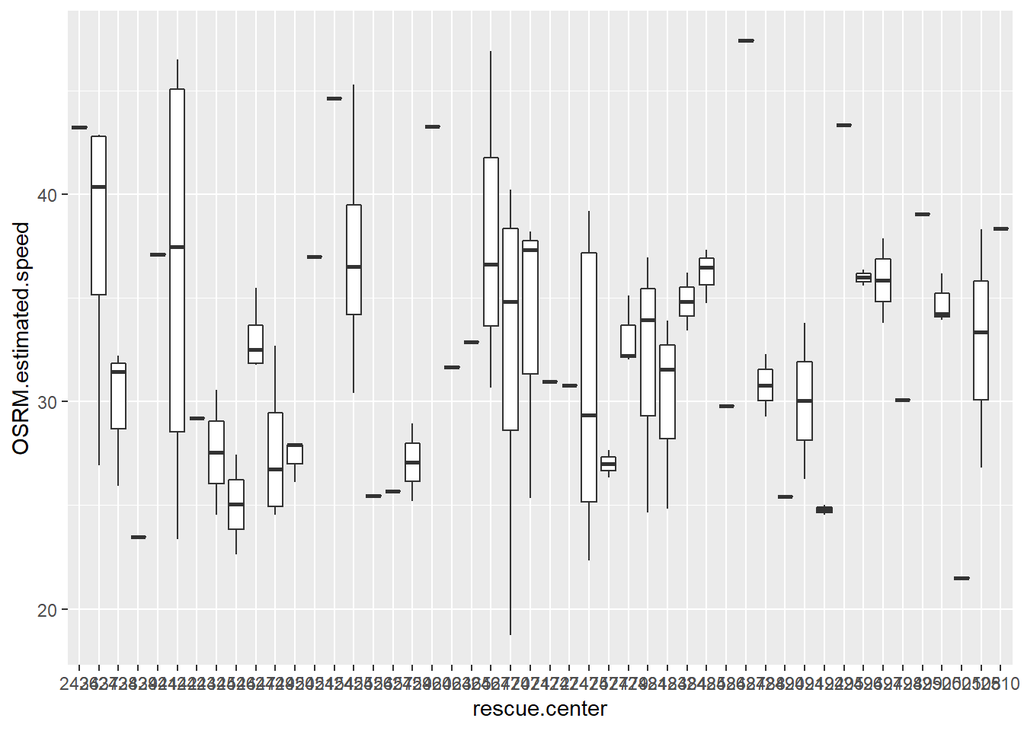

```r
data.fe.sample %>%
  ggplot(aes(x=rescue.center, y=OSRM.estimated.speed)) +
  geom_boxplot()
```

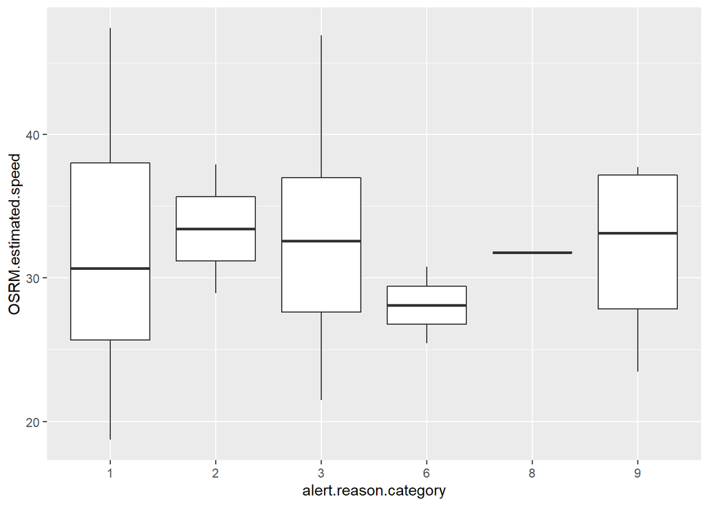

```r
data.fe.sample %>%
  ggplot(aes(x=alert.reason.category, y=OSRM.estimated.speed)) +
  geom_boxplot()
```

### 4.2 Add month, day of week

```r
data.fe$month <-month(as.Date(as.character(data.fe$date.key.selection), "%Y%m%d"))

data.fe$weekdays <-weekdays(as.Date(as.character(data.fe$date.key.selection), "%Y%m%d"))
```

Same for x_test

```r
x_test$month <-month(as.Date(as.character(x_test$date.key.selection), "%Y%m%d"))

x_test$weekdays <-weekdays(as.Date(as.character(x_test$date.key.selection), "%Y%m%d"))
```

```r
data.fe$hours <-as.hms(formatC(as.integer(data.fe$time.key.selection), big.mark = ":", big.interval = 2L))
data.fe$hours <- replace(data.fe$hours, is.na(data.fe$hours), "00:00:00")
```

Same for x_test

```r
x_test$hours <-as.hms(formatC(as.integer(x_test$time.key.selection), big.mark = ":", big.interval = 2L))
x_test$hours <- replace(x_test$hours, is.na(x_test$hours), "00:00:00")
```

```r
data.fe$hours <- substr(data.fe$hours, 1, 2)
x_test$hours <- substr(x_test$hours, 1, 2)
```

```r
table(data.fe$month)
```

```
##
##     1     2     3     4     5     6     7     8    10    11    12
## 19593 17254 18945 17738 18989 19210 19939 16409 19269 19186 19683
```

```r
prop.table(table(data.fe$month))
```

```
##
##          1          2          3          4          5          6          7
## 0.09501249 0.08366996 0.09187014 0.08601702 0.09208351 0.09315520 0.09669035
##          8         10         11         12
## 0.07957229 0.09344131 0.09303882 0.09544892
```

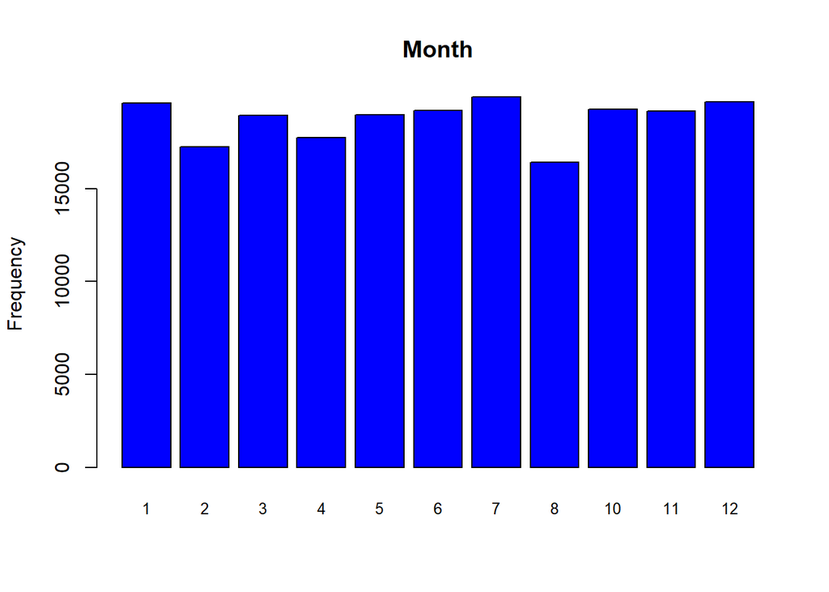

```r
barplot(table(data.fe$month),horiz = F,cex.names=0.8,col="blue",main="Month",ylab="Frequency", plot=TRUE)
```

```r
table(data.fe$weekdays)
```

```
##
## dimanche    jeudi    lundi    mardi mercredi   samedi vendredi
##    28179    29428    31206    29393    29340    28255    30414
```

```r
prop.table(table(data.fe$weekdays))
```

```
##
##  dimanche     jeudi     lundi     mardi  mercredi    samedi  vendredi
## 0.1366486 0.1427054 0.1513275 0.1425357 0.1422787 0.1370172 0.1474868
```

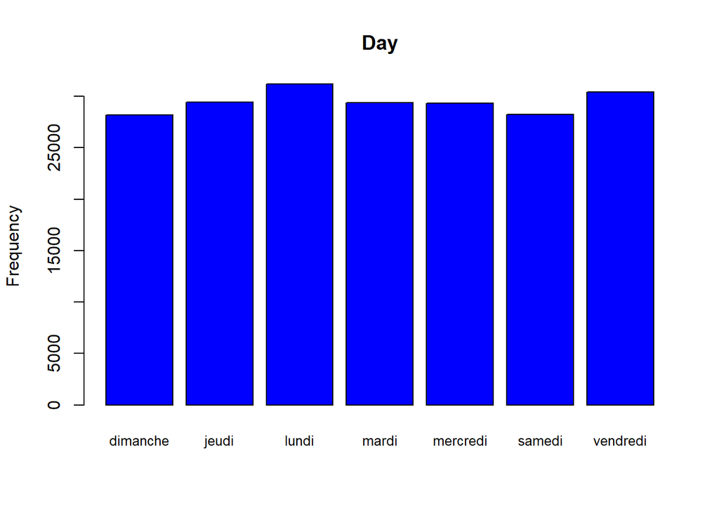

```r
barplot(table(data.fe$weekdays),horiz = F,cex.names=0.8,col="blue",main="Day",ylab="Frequency", plot=TRUE)
```

```r
table(data.fe$hours)
```

```
##
##    00    01    02    03    04    05    06    07    08    09    10    11    12
##  7458  6363  5173  4731  4163  3985  4394  5603  7640  9307  9954 10635 11387
##    13    14    15    16    17    18    19    20    21    22    23
## 11207 10801 10365 10237 10356 10758 11439 11177 10497  9813  8772
```

```r
prop.table(table(data.fe$hours))
```

```
##
##         00         01         02         03         04         05         06
## 0.03616614 0.03085615 0.02508547 0.02294208 0.02018767 0.01932449 0.02130786
##         07         08         09         10         11         12         13
## 0.02717067 0.03704871 0.04513251 0.04827001 0.05157239 0.05521907 0.05434619
##         14         15         16         17         18         19         20
## 0.05237737 0.05026307 0.04964236 0.05021943 0.05216885 0.05547123 0.05420071
##         21         22         23
## 0.05090318 0.04758626 0.04253813
```

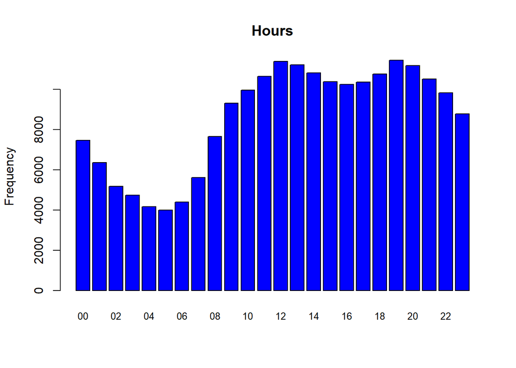

```r
barplot(table(data.fe$hours),horiz = F,cex.names=0.8,col="blue",main="Hours",ylab="Frequency", plot=TRUE)
```

We can now remove date.key.selection and time.key.selection

```r
data.fe<-data.fe[,-c(13,14)]
```

Same for x_test

```r
x_test<-x_test[,-c(13,14)]
```

Convert time and date build variables into factors

```r
data.fe$hours <- as.factor(data.fe$hours)
data.fe$weekdays <- as.factor(data.fe$weekdays)
data.fe$month <- as.factor(data.fe$month)
```

```r
x_test$hours <- as.factor(x_test$hours)
x_test$weekdays <- as.factor(x_test$weekdays)
x_test$month <- as.factor(x_test$month)
```

### 4.3 Order of the brigade

For the same event, multiple brigade can leave. It is worth to take into account that it might be a correlation between the order of the brigade to leave and the time for preparation. Once we have classify those brigade, we will be able to remove the id of the intervention.

```r
data.fe$intervention %>% as.factor() %>% str
```

```
##  Factor w/ 197642 levels "12649492","12650159",..: 112323 2158 169535 8547 174237 5561 137814 17650 144330 144197 ...
```

```r
data.fe$emergency.vehicle.selection %>% str
```

```
##  int [1:206215] 5105452 4720915 5365374 4741586 5381209 4731603 5196431 4774057 5277444 5277017 ...
```

```r
204987-196480
```

```
## [1] 8507
```

```r
x_test$intervention %>% as.factor() %>% str
```

```
##  Factor w/ 102466 levels "12649492","12650159",..: 73849 56296 64950 86532 68610 73049 784 52060 18501 92121 ...
```

Plot frequency order of id intervention.

```r
a<-data.fe %>%
        group_by(intervention)%>%
         tally()
```

```r
b<-x_test %>%
        group_by(intervention)%>%
         tally()
```

```r
a %>% setDT
a %>% str
```

```
## Classes 'data.table' and 'data.frame':   197642 obs. of  2 variables:
##  $ intervention: int  12649492 12650159 12651734 12651765 12651790 12651791 12651829 12651860 12651907 12651960 ...
##  $ n           : int  1 1 1 1 1 1 1 1 1 1 ...
```

```r
b %>% setDT
```

```r
data.fe<-merge(a,data.fe, by.x = 'intervention', by.y = 'intervention', all=FALSE)
```

```r
x_test<-merge(b,x_test, by.x = 'intervention', by.y = 'intervention', all=FALSE)
```

Rename and convert as factor

```r
data.fe$n<-data.fe$n %>% as.factor
x_test$n<-x_test$n %>% as.factor
```

Now that we have intervention frequency as factor, we can remove intervention ID

```r
data.fe<-data.fe[,-c(1)]
x_test<-x_test[,-c(1)]
```

### 4.4 GPS

We decide to remove GPS data since we have the same data.

```r
data.fe<-data.fe[,-c(18,19)]
x_test<-x_test[,-c(18,19)]
```

## 5. Correlation analysis

Update data.quanti and data.quali

```r
colnames(data.fe)
```

```
##  [1] "n"
##  [2] "emergency.vehicle.selection"
##  [3] "alert.reason.category"
##  [4] "alert.reason"
##  [5] "intervention.on.public.roads"
##  [6] "floor"
##  [7] "location.of.the.event"
##  [8] "longitude.intervention"
##  [9] "latitude.intervention"
## [10] "emergency.vehicle"
## [11] "emergency.vehicle.type"
## [12] "rescue.center"
## [13] "status.preceding.selection"
## [14] "delta.status.preceding.selection.selection"
## [15] "departed.from.its.rescue.center"
## [16] "longitude.before.departure"
## [17] "latitude.before.departure"
## [18] "OSRM.estimated.distance"
## [19] "OSRM.estimated.duration"
## [20] "delta.selection.departure"
## [21] "delta.departure.presentation"
## [22] "delta.selection.presentation"
## [23] "OSRM.estimated.speed"
## [24] "month"
## [25] "weekdays"
## [26] "hours"
```

```r
str(data.fe)
```

```
## Classes 'data.table' and 'data.frame':   206215 obs. of  26 variables:
##  $ n                                         : Factor w/ 12 levels "1","2","3","4",..: 1 1 1 1 1 1 1 1 1 1 ...
##  $ emergency.vehicle.selection               : int  4714126 4714817 4713701 4713715 4713916 4713754 4713742 4713752 4713762 4713791 ...
##  $ alert.reason.category                     : Factor w/ 9 levels "1","2","3","4",..: 1 1 3 3 3 1 1 3 1 3 ...
##  $ alert.reason                              : Factor w/ 122 levels "1911","1912",..: 6 7 60 32 60 3 4 60 3 31 ...
##  $ intervention.on.public.roads              : Factor w/ 2 levels "0","1": 1 1 1 2 1 1 2 1 2 1 ...
##  $ floor                                     : Factor w/ 20 levels "-2","-1","0",..: 8 6 10 3 4 3 3 3 3 3 ...
##  $ location.of.the.event                     : Factor w/ 210 levels "100","101","102",..: 36 21 39 48 39 65 48 1 48 49 ...
##  $ longitude.intervention                    : num  2.34 2.28 2.33 2.3 2.2 ...
##  $ latitude.intervention                     : num  48.9 48.9 48.9 48.9 48.9 ...
##  $ emergency.vehicle                         : Factor w/ 639 levels "1815","1823",..: 318 92 488 398 442 598 308 445 69 125 ...
##  $ emergency.vehicle.type                    : Factor w/ 41 levels "AR","BEAA BSPP",..: 24 24 37 37 37 15 24 37 24 8 ...
##  $ rescue.center                             : Factor w/ 79 levels "2418","2434",..: 41 3 63 15 58 5 72 27 28 6 ...
##  $ status.preceding.selection                : Factor w/ 2 levels "Disponible","RentrÃ©": 2 2 2 2 2 2 1 2 2 2 ...
##  $ delta.status.preceding.selection.selection: int  8293 16251 875 606 4693 86 7 1382 2062 968 ...
##  $ departed.from.its.rescue.center           : Factor w/ 2 levels "0","1": 2 2 2 2 2 2 1 2 2 2 ...
##  $ longitude.before.departure                : num  2.33 2.28 2.34 2.29 2.18 ...
##  $ latitude.before.departure                 : num  48.9 48.9 48.9 48.9 48.9 ...
##  $ OSRM.estimated.distance                   : num  1283 2347 1525 1812 2586 ...
##  $ OSRM.estimated.duration                   : num  214 218 173 198 280 ...
##  $ delta.selection.departure                 : num  469 457 469 488 314 374 491 582 548 641 ...
##  $ delta.departure.presentation              : num  138 150 158 119 130 124 196 119 143 124 ...
##  $ delta.selection.presentation              : num  331 306 310 369 184 250 295 462 404 516 ...
##  $ OSRM.estimated.speed                      : num  21.6 38.8 31.7 33 33.2 ...
##  $ month                                     : Factor w/ 11 levels "1","2","3","4",..: 1 1 1 1 1 1 1 1 1 1 ...
##  $ weekdays                                  : Factor w/ 7 levels "dimanche","jeudi",..: 3 3 3 3 3 3 3 3 3 3 ...
##  $ hours                                     : Factor w/ 24 levels "00","01","02",..: 4 10 1 1 2 1 1 1 1 1 ...
##  - attr(*, ".internal.selfref")=<externalptr>
```

```r
data.quanti<-data.fe[,c(23,22,19,18,17,16,14,9,8,2)]

data.quanti.y<-data.fe[,c(23,22,21,20,19,18,17,16,14,9,8,2)]

data.quali<-data.fe[,-c(23,22,21,20,19,18,17,16,14,9,8,2)]

data.quali.y<-data.fe[,-c(23,22,19,18,17,16,14,9,8,2)]

str(data.quanti)
```

```
## Classes 'data.table' and 'data.frame':   206215 obs. of  10 variables:
##  $ OSRM.estimated.speed                      : num  21.6 38.8 31.7 33 33.2 ...
##  $ delta.selection.presentation              : num  331 306 310 369 184 250 295 462 404 516 ...
##  $ OSRM.estimated.duration                   : num  214 218 173 198 280 ...
##  $ OSRM.estimated.distance                   : num  1283 2347 1525 1812 2586 ...
##  $ latitude.before.departure                 : num  48.9 48.9 48.9 48.9 48.9 ...
##  $ longitude.before.departure                : num  2.33 2.28 2.34 2.29 2.18 ...
##  $ delta.status.preceding.selection.selection: int  8293 16251 875 606 4693 86 7 1382 2062 968 ...
##  $ latitude.intervention                     : num  48.9 48.9 48.9 48.9 48.9 ...
##  $ longitude.intervention                    : num  2.34 2.28 2.33 2.3 2.2 ...
##  $ emergency.vehicle.selection               : int  4714126 4714817 4713701 4713715 4713916 4713754 4713742 4713752 4713762 4713791 ...
##  - attr(*, ".internal.selfref")=<externalptr>
```

```r
str(data.quanti.y)
```

```
## Classes 'data.table' and 'data.frame':   206215 obs. of  12 variables:
##  $ OSRM.estimated.speed                      : num  21.6 38.8 31.7 33 33.2 ...
##  $ delta.selection.presentation              : num  331 306 310 369 184 250 295 462 404 516 ...
##  $ delta.departure.presentation              : num  138 150 158 119 130 124 196 119 143 124 ...
##  $ delta.selection.departure                 : num  469 457 469 488 314 374 491 582 548 641 ...
##  $ OSRM.estimated.duration                   : num  214 218 173 198 280 ...
##  $ OSRM.estimated.distance                   : num  1283 2347 1525 1812 2586 ...
##  $ latitude.before.departure                 : num  48.9 48.9 48.9 48.9 48.9 ...
##  $ longitude.before.departure                : num  2.33 2.28 2.34 2.29 2.18 ...
##  $ delta.status.preceding.selection.selection: int  8293 16251 875 606 4693 86 7 1382 2062 968 ...
##  $ latitude.intervention                     : num  48.9 48.9 48.9 48.9 48.9 ...
##  $ longitude.intervention                    : num  2.34 2.28 2.33 2.3 2.2 ...
##  $ emergency.vehicle.selection               : int  4714126 4714817 4713701 4713715 4713916 4713754 4713742 4713752 4713762 4713791 ...
##  - attr(*, ".internal.selfref")=<externalptr>
```

```r
str(data.quali)
```

```
## Classes 'data.table' and 'data.frame':   206215 obs. of  14 variables:
##  $ n                              : Factor w/ 12 levels "1","2","3","4",..: 1 1 1 1 1 1 1 1 1 1 ...
##  $ alert.reason.category          : Factor w/ 9 levels "1","2","3","4",..: 1 1 3 3 3 1 1 3 1 3 ...
##  $ alert.reason                   : Factor w/ 122 levels "1911","1912",..: 6 7 60 32 60 3 4 60 3 31 ...
##  $ intervention.on.public.roads   : Factor w/ 2 levels "0","1": 1 1 1 2 1 1 2 1 2 1 ...
##  $ floor                          : Factor w/ 20 levels "-2","-1","0",..: 8 6 10 3 4 3 3 3 3 3 ...
##  $ location.of.the.event          : Factor w/ 210 levels "100","101","102",..: 36 21 39 48 39 65 48 1 48 49 ...
##  $ emergency.vehicle              : Factor w/ 639 levels "1815","1823",..: 318 92 488 398 442 598 308 445 69 125 ...
##  $ emergency.vehicle.type         : Factor w/ 41 levels "AR","BEAA BSPP",..: 24 24 37 37 37 15 24 37 24 8 ...
##  $ rescue.center                  : Factor w/ 79 levels "2418","2434",..: 41 3 63 15 58 5 72 27 28 6 ...
##  $ status.preceding.selection     : Factor w/ 2 levels "Disponible","RentrÃ©": 2 2 2 2 2 2 1 2 2 2 ...
##  $ departed.from.its.rescue.center: Factor w/ 2 levels "0","1": 2 2 2 2 2 2 1 2 2 2 ...
##  $ month                          : Factor w/ 11 levels "1","2","3","4",..: 1 1 1 1 1 1 1 1 1 1 ...
##  $ weekdays                       : Factor w/ 7 levels "dimanche","jeudi",..: 3 3 3 3 3 3 3 3 3 3 ...
##  $ hours                          : Factor w/ 24 levels "00","01","02",..: 4 10 1 1 2 1 1 1 1 1 ...
##  - attr(*, ".internal.selfref")=<externalptr>
```

```r
str(data.quali.y)
```

```
## Classes 'data.table' and 'data.frame':   206215 obs. of  16 variables:
##  $ n                              : Factor w/ 12 levels "1","2","3","4",..: 1 1 1 1 1 1 1 1 1 1 ...
##  $ alert.reason.category          : Factor w/ 9 levels "1","2","3","4",..: 1 1 3 3 3 1 1 3 1 3 ...
##  $ alert.reason                   : Factor w/ 122 levels "1911","1912",..: 6 7 60 32 60 3 4 60 3 31 ...
##  $ intervention.on.public.roads   : Factor w/ 2 levels "0","1": 1 1 1 2 1 1 2 1 2 1 ...
##  $ floor                          : Factor w/ 20 levels "-2","-1","0",..: 8 6 10 3 4 3 3 3 3 3 ...
##  $ location.of.the.event          : Factor w/ 210 levels "100","101","102",..: 36 21 39 48 39 65 48 1 48 49 ...
##  $ emergency.vehicle              : Factor w/ 639 levels "1815","1823",..: 318 92 488 398 442 598 308 445 69 125 ...
##  $ emergency.vehicle.type         : Factor w/ 41 levels "AR","BEAA BSPP",..: 24 24 37 37 37 15 24 37 24 8 ...
##  $ rescue.center                  : Factor w/ 79 levels "2418","2434",..: 41 3 63 15 58 5 72 27 28 6 ...
##  $ status.preceding.selection     : Factor w/ 2 levels "Disponible","RentrÃ©": 2 2 2 2 2 2 1 2 2 2 ...
##  $ departed.from.its.rescue.center: Factor w/ 2 levels "0","1": 2 2 2 2 2 2 1 2 2 2 ...
##  $ delta.selection.departure      : num  469 457 469 488 314 374 491 582 548 641 ...
##  $ delta.departure.presentation   : num  138 150 158 119 130 124 196 119 143 124 ...
##  $ month                          : Factor w/ 11 levels "1","2","3","4",..: 1 1 1 1 1 1 1 1 1 1 ...
##  $ weekdays                       : Factor w/ 7 levels "dimanche","jeudi",..: 3 3 3 3 3 3 3 3 3 3 ...
##  $ hours                          : Factor w/ 24 levels "00","01","02",..: 4 10 1 1 2 1 1 1 1 1 ...
##  - attr(*, ".internal.selfref")=<externalptr>
```

After engineering new features and before starting the modeling, we have to visualize the relations between our parameters using a correlation matrix. For this, we need to change all the factor features into a numerical format. The visualization uses the corrplot function from the eponymous package. Corrplot gives us great flexibility in manipulating the style of our plot.

What we see below, are the color-coded correlation coefficients for each combination of two features. In simplest terms: this shows whether two features are connected so that one changes with a predictable trend if you change the other. The closer this coefficient is to zero the weaker is the correlation. Both 1 and -1 are the ideal cases of perfect correlation and anti-correlation (dark blue and dark red in the plots below).

Here, we are of course interested if and how strongly our correlate with the ys. But we also want to know whether our potential predictors are correlated among each other, so that we can reduce the colinearity in our data set and improve the robustness of our prediction.

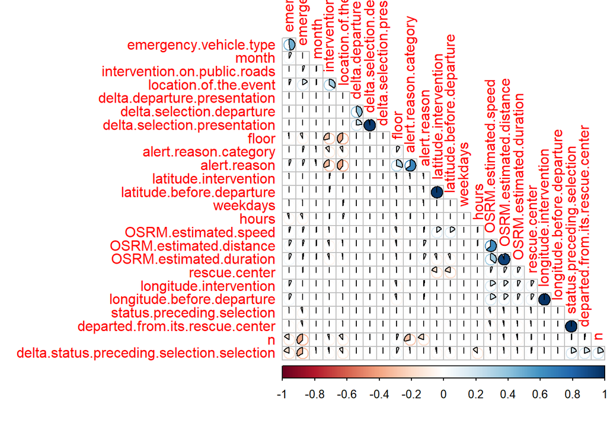

```r
data.fe %>%
  select(-emergency.vehicle.selection) %>%
  mutate(n = as.integer(n),
         alert.reason = as.integer(alert.reason),
         floor = as.integer(floor),
         emergency.vehicle = as.integer(emergency.vehicle),
         rescue.center = as.integer(rescue.center),
         delta.selection.presentation = as.integer(delta.selection.presentation),
         month = as.integer(month),
         hours = as.integer(hours),
        weekdays = as.integer(weekdays),
         alert.reason.category = as.integer(alert.reason.category),
         intervention.on.public.roads = as.integer(intervention.on.public.roads),
         location.of.the.event = as.integer(location.of.the.event),
         emergency.vehicle.type = as.integer(emergency.vehicle.type),
         status.preceding.selection = as.integer(status.preceding.selection),
          departed.from.its.rescue.center = as.integer(departed.from.its.rescue.center))%>%

  cor(use="complete.obs", method = "spearman") %>%
  corrplot(type="lower", method="pie",order="hclust",
         diag=FALSE)
```

Add coefficients

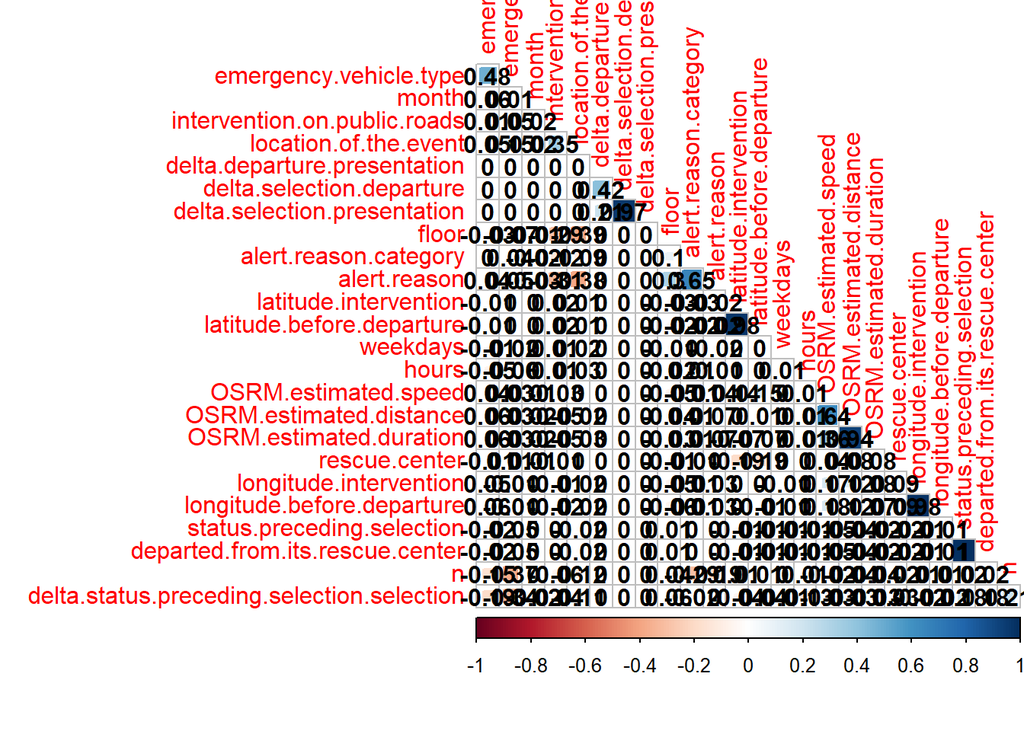

```r
data.fe %>%
  select(-emergency.vehicle.selection) %>%
  mutate(n = as.integer(n),
         alert.reason = as.integer(alert.reason),
         floor = as.integer(floor),
         emergency.vehicle = as.integer(emergency.vehicle),
         rescue.center = as.integer(rescue.center),
         delta.selection.presentation = as.integer(delta.selection.presentation),
         month = as.integer(month),
         hours = as.integer(hours),
        weekdays = as.integer(weekdays),
         alert.reason.category = as.integer(alert.reason.category),
         intervention.on.public.roads = as.integer(intervention.on.public.roads),
         location.of.the.event = as.integer(location.of.the.event),
         emergency.vehicle.type = as.integer(emergency.vehicle.type),
         status.preceding.selection = as.integer(status.preceding.selection),
          departed.from.its.rescue.center = as.integer(departed.from.its.rescue.center))%>%

  cor(use="complete.obs", method = "spearman") %>%
  corrplot(type="lower", method="square",order="hclust",
         addCoef.col = "black", diag=FALSE)
```

We find :

- Alert reason is correlated to alert reason.category (0,65).
- OSRM estimated speed and OSRM distance are correlated (this is quite normal). We decide to keep the 2 features.
- Status departure before selection and departed from its rescue center are perfectly correlated. We remove status departure before selection.
- Longitude.before.departure and longitude.intervention are highly correlated. We can remove longitude.before.departure
- Latitude.before.departure and lat.intervention are highly correlated. We can remove lat.before.departure
- Except for ORSM features, there is no high correlated feature.

```r
data.fe<-data.fe[,-c("alert.reason","status.preceding.selection","longitude.before.departure","latitude.before.departure")]
```

```r
x_test<-x_test[,-c("alert.reason","status.preceding.selection","longitude.before.departure","latitude.before.departure")]
```

## 6. Boosted Tree with XGB

Boosted Tree aka XGBoost. XGBoost is a well-known and efficient open source implementation of the improved gradient tree algorithm.  
Gradient boosting is a supervised learning algorithm, which attempts to accurately predict a target variable by combining estimates from a simpler and weaker set of models. GBoost reduces a regularized objective function (L1 and L2) that combines a convex loss function (based on the difference between predicted and target outputs) and a penalty condition for model complexity (in other words, regression tree functions). Training continues iteratively, adding new trees that predict residuals or errors from previous trees that are then combined with the previous trees to make the final prediction.

In other words we are building a tree and looks which value is predicted poorly and assign to it higher weigh in our prediction.

Let us build and predict our model with 100 maximum number of boosting iterations.

### 6.1 Sample

Store final dataset

```r
dataset<-data.fe
```

Sample data

```r
n_train <- round(0.8 * nrow(dataset))
train_indices <- sample(1:nrow(dataset), n_train)
trainset <- dataset[train_indices, ]
testset <- dataset[-train_indices, ]
```

### 6.2 Yo : Selection - Departure

Store only y0 target value

```r
trainset0_y0<-trainset$delta.selection.departure
trainset0<-trainset[,-c("delta.departure.presentation","delta.selection.presentation","delta.selection.departure")]
testset0_y0<-testset$delta.selection.departure
testset0<-testset[,-c("delta.departure.presentation","delta.selection.presentation","delta.selection.departure")]
```

Create one-hot matrix for cat variable. with sparse-matrix

```r
sparse_matrix <- sparse.model.matrix( ~ ., data = trainset0)[,-1]
```

Store into xgb Matrix

```r
dtrain1 <- xgb.DMatrix(sparse_matrix,label = trainset$delta.selection.departure)
```

Set parameters for our xgb tree

```r
xgb_params <- list(colsample_bytree = 0.7, #variables per tree
                   subsample = 0.7, #data subset per tree
                   booster = "gbtree",
                   max_depth = 5, #tree levels
                   eta = 0.3, #shrinkage
                   eval_metric = "rmse",
                   objective = "reg:linear",
                   seed = 4321
                   )
```

train our model

```r
#set.seed(4321)
gb_0_dt <- xgb.train(params = xgb_params,
                   data = dtrain1,
                   print_every_n = 100,
                   nrounds = 100)
```

```
## [22:41:38] WARNING: amalgamation/../src/objective/regression_obj.cu:174: reg:linear is now deprecated in favor of reg:squarederror.
```

Plot the 30 first important features in our model

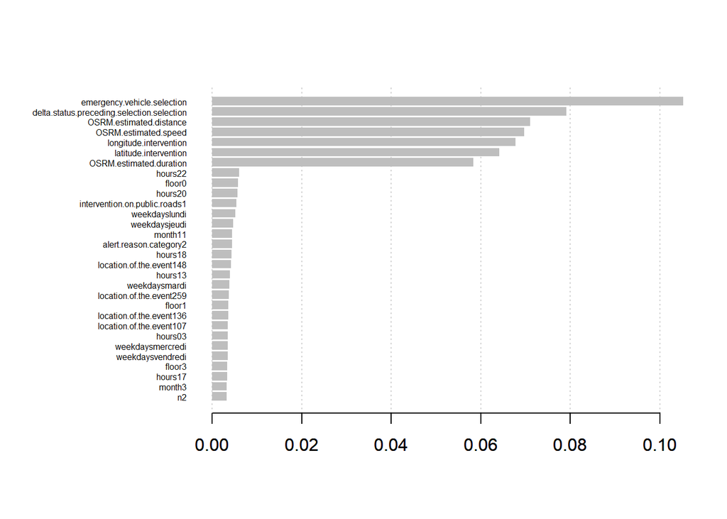

```r
importance_matrix <- xgb.importance(model = gb_0_dt)
xgb.plot.importance(importance_matrix[1:30,])
```

Predict with testset0

```r
sparse_matrix2 <- sparse.model.matrix( ~ ., data =testset0 )[,-1]
```

Store into xgb Matrix

```r
dtest <- xgb.DMatrix(sparse_matrix2,label=testset$delta.selection.departure)
```

Predict

```r
pred_xgboost_y0 <- predict(gb_0_dt,dtest)
```

```r
pred_xgboost_y0 %>% head
```

```
## [1] 466.4048 548.4099 483.5152 446.1328 484.6180 570.6462
```

```r
testset$delta.selection.departure %>% head
```

```
## [1] 488 314 641 387 585 629
```

Compute MSE, MAE, R2

```r
postResample(pred = pred_xgboost_y0, obs = testset$delta.selection.departure)
```

```
##         RMSE     Rsquared          MAE
## 1.141044e+02 1.423638e-05 8.733089e+01
```

### 6.3 Y1 : Departure - Presentation

Store only y1 target value

```r
trainset1_y1<-trainset$delta.departure.presentation
trainset1<-trainset[,-c("delta.selection.departure","delta.selection.presentation","delta.departure.presentation")]
testset1_y1<-testset$delta.departure.presentation
testset1<-testset[,-c("delta.selection.departure","delta.selection.presentation","delta.departure.presentation")]
```

Create one-hot matrix for cat variable. with sparse-matrix

```r
sparse_matrix <- sparse.model.matrix( ~ ., data = trainset1)[,-1]
```

Store into xgb Matrix

```r
dtrain2 <- xgb.DMatrix(sparse_matrix,label = trainset$delta.departure.presentation)
```

Set parameters for our xgb tree

```r
xgb_params <- list(colsample_bytree = 0.5, #variables per tree
                   subsample = 0.5, #data subset per tree
                   booster = "gbtree",
                   max_depth = 3, #tree levels
                   eta = 0.3, #shrinkage
                   eval_metric = "rmse",
                   objective = "reg:linear",
                   seed = 4321
                   )
```

train our model

```r
#set.seed(4321)
gb_1_dt <- xgb.train(params = xgb_params,
                   data = dtrain2,
                   print_every_n = 100,
                   nrounds = 100)
```

```
## [22:41:54] WARNING: amalgamation/../src/objective/regression_obj.cu:174: reg:linear is now deprecated in favor of reg:squarederror.
```

Plot the 30 first important features in our model

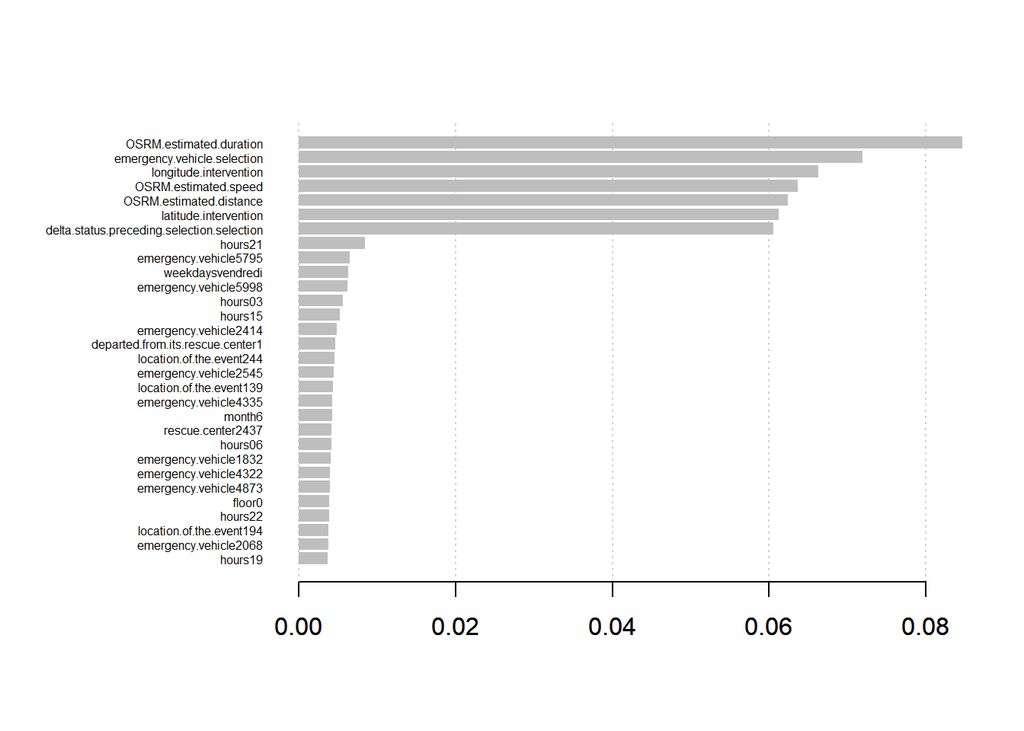

```r
importance_matrix <- xgb.importance(model = gb_1_dt)
xgb.plot.importance(importance_matrix[1:30,])
```

Predict

```r
sparse_matrix2 <- sparse.model.matrix( ~ ., data =testset1 )[,-1]
```

Store into xgb Matrix

```r
dtest <- xgb.DMatrix(sparse_matrix2,label=testset$delta.departure.presentation)
```

Predict

```r
pred_xgboost_y1 <- predict(gb_1_dt,dtest)
```

```r
pred_xgboost_y1 %>% head
```

```
## [1] 144.1933 141.6069 136.6029 139.6789 143.3554 154.1176
```

```r
testset$delta.departure.presentation %>% head
```

```
## [1] 119 130 124 134 191 133
```

```r
postResample(pred = pred_xgboost_y1, obs = testset$delta.departure.presentation)
```

```
##         RMSE     Rsquared          MAE
## 2.480371e+01 4.528237e-06 1.969964e+01
```

### 6.4 Ys : Compute global

```r
pred_xgboost_ys=pred_xgboost_y0+pred_xgboost_y1
pred_xgboost=data.frame(pred_xgboost_y0,pred_xgboost_y1,pred_xgboost_ys)

pred_xgboost %>% head
```

```
##   pred_xgboost_y0 pred_xgboost_y1 pred_xgboost_ys
## 1        466.4048        144.1933        610.5981
## 2        548.4099        141.6069        690.0168
## 3        483.5152        136.6029        620.1182
## 4        446.1328        139.6789        585.8118
## 5        484.6180        143.3554        627.9734
## 6        570.6462        154.1176        724.7638
```

```r
testset$delta.selection.presentation %>% head
```

```
## [1] 369 184 516 252 393 495
```

```r
postResample(pred = pred_xgboost_ys, obs = testset$delta.departure.presentation)
```

```
##         RMSE     Rsquared          MAE
## 4.907659e+02 8.144267e-05 4.900011e+02
```

### 6.5 Use feature importance to create group for factor variables for futur regression

For Y0

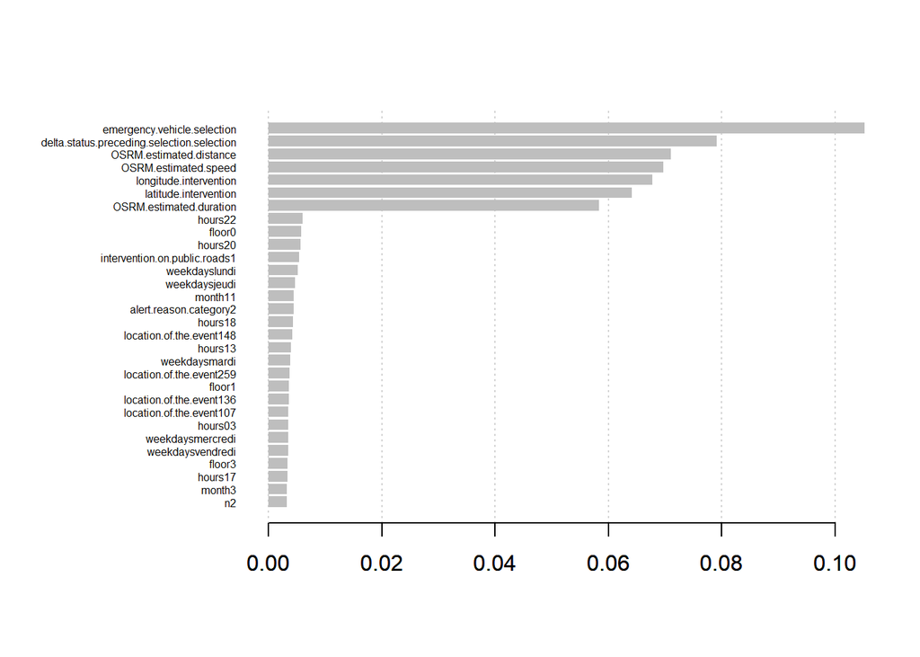

```r
importance_matrix_y0 <- xgb.importance(model = gb_0_dt)
xgb.plot.importance(importance_matrix_y0[1:30,])
```

```r
importance_matrix_y0[1:30,]
```

```
##                                        Feature        Gain        Cover
##  1:                emergency.vehicle.selection 0.105209759 8.103345e-02
##  2: delta.status.preceding.selection.selection 0.079076762 4.487040e-02
##  3:                    OSRM.estimated.distance 0.071026576 5.202298e-02
##  4:                       OSRM.estimated.speed 0.069668037 4.177032e-02
##  5:                     longitude.intervention 0.067742995 3.357661e-02
##  6:                      latitude.intervention 0.064160738 2.350619e-02
##  7:                    OSRM.estimated.duration 0.058315183 3.938972e-02
##  8:                                    hours22 0.006056974 2.006816e-03
##  9:                                     floor0 0.005826382 3.028234e-04
## 10:                                    hours20 0.005699413 4.766535e-05
## 11:              intervention.on.public.roads1 0.005384650 4.388495e-03
## 12:                              weekdayslundi 0.005165175 2.032395e-03
## 13:                              weekdaysjeudi 0.004655688 2.603261e-05
## 14:                                    month11 0.004418625 3.970367e-05
```

[output cut: 49 more lines]

We find : - Delta status preceding selection - Hours - Lat intervention - Long intervention - emergency vehicle type VSAV$VD (group is or not) - emergency.vehicle.typePSE - emergency.vehicle.typeVID - emergency.vehicle.typeCRF - emergency.vehicle.typeFNPC - ORSRM data - Rescue center 2474,2477,2475,2439, 2435,2464, 2488, 2493(group is or not) - Alert-reason-cat-03 -2 -departed from its rescue center1

We regroup the types of emergency vehicle, the rescue centers and the alert reason category

```r
trainset0.regroup <- trainset0
testset0.regroup <- testset0

trainset0.regroup = trainset0.regroup %>%
    mutate(emergency.vehicle.type.regroup = case_when(emergency.vehicle.type == "VSAV BSPP" ~  1,
                                  emergency.vehicle.type =="PSE" ~  1,
                                  emergency.vehicle.type == "VID" ~  1,
                                  emergency.vehicle.type == "CRF" ~  1,
                                  emergency.vehicle.type == "FNPC" ~  1,
                                  TRUE ~ 0))
trainset0.regroup = trainset0.regroup %>%
    mutate(rescue.center.regroup = case_when(rescue.center == "2474" ~  1,
                                  rescue.center =="2477" ~  1,
                                  rescue.center == "2475" ~  1,
                                  rescue.center == "2439" ~  1,
                                  rescue.center == "2435" ~  1,
                                  rescue.center == "2464" ~  1,
                                  rescue.center == "2488" ~  1,
                                  rescue.center == "2493" ~  1,
                                  TRUE ~ 0))


testset0.regroup = testset0.regroup %>%
    mutate(emergency.vehicle.type.regroup = case_when(emergency.vehicle.type == "VSAV BSPP" ~  1,
                                  emergency.vehicle.type =="PSE" ~  1,
                                  emergency.vehicle.type == "VID" ~  1,
                                  emergency.vehicle.type == "CRF" ~  1,
                                  emergency.vehicle.type == "FNPC" ~  1,
                                  TRUE ~ 0))
testset0.regroup = testset0.regroup  %>%
    mutate(rescue.center.regroup = case_when(rescue.center == "2474" ~  1,
                                  rescue.center =="2477" ~  1,
                                  rescue.center == "2475" ~  1,
                                  rescue.center == "2439" ~  1,
                                  rescue.center == "2435" ~  1,
                                  rescue.center == "2464" ~  1,
                                  rescue.center == "2488" ~  1,
                                  rescue.center == "2493" ~  1,
                                  TRUE ~ 0))
```

Drop not-important features in trainset0

```r
trainset0.regroup$rescue.center<-NULL
trainset0.regroup$n<-NULL
trainset0.regroup$emergency.vehicle.type<-NULL
trainset0.regroup$floor<-NULL
trainset0.regroup$emergency.vehicle<-NULL
trainset0.regroup$weekdays<-NULL
trainset0.regroup$intervention.on.public.roads<-NULL
trainset0.regroup$location.of.the.event<-NULL
trainset0.regroup$month<-NULL
```

```r
testset0.regroup$rescue.center<-NULL
testset0.regroup$emergency.vehicle.type<-NULL

testset0.regroup$n<-NULL
testset0.regroup$floor<-NULL
testset0.regroup$emergency.vehicle<-NULL
testset0.regroup$weekdays<-NULL
testset0.regroup$intervention.on.public.roads<-NULL
testset0.regroup$location.of.the.event<-NULL
testset0.regroup$month<-NULL
```

Same for x_test

```r
x_test0.regroup <- x_test

x_test0.regroup = x_test0.regroup %>%
    mutate(emergency.vehicle.type.regroup = case_when(emergency.vehicle.type == "VSAV BSPP" ~  1,
                                  emergency.vehicle.type =="PSE" ~  1,
                                  emergency.vehicle.type == "VID" ~  1,
                                  emergency.vehicle.type == "CRF" ~  1,
                                  emergency.vehicle.type == "FNPC" ~  1,
                                  TRUE ~ 0))
x_test0.regroup = x_test0.regroup %>%
    mutate(rescue.center.regroup = case_when(rescue.center == "2474" ~  1,
                                  rescue.center =="2477" ~  1,
                                  rescue.center == "2475" ~  1,
                                  rescue.center == "2439" ~  1,
                                  rescue.center == "2435" ~  1,
                                  rescue.center == "2464" ~  1,
                                  rescue.center == "2488" ~  1,
                                  rescue.center == "2493" ~  1,
                                  TRUE ~ 0))
```

```r
x_test0.regroup$rescue.center<-NULL
x_test0.regroup$emergency.vehicle.type<-NULL

x_test0.regroup$n<-NULL
x_test0.regroup$floor<-NULL
x_test0.regroup$emergency.vehicle<-NULL
x_test0.regroup$weekdays<-NULL
x_test0.regroup$intervention.on.public.roads<-NULL
x_test0.regroup$location.of.the.event<-NULL
x_test0.regroup$month<-NULL
```

For Y1

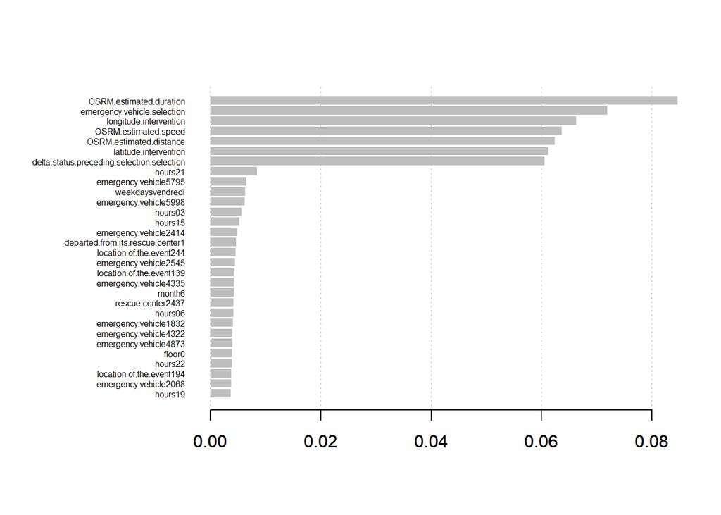

```r
importance_matrix_y1 <- xgb.importance(model = gb_1_dt)
xgb.plot.importance(importance_matrix_y1[1:30,])
```

```r
importance_matrix_y1[1:30,]
```

```
##                                        Feature        Gain        Cover
##  1:                    OSRM.estimated.duration 0.084658030 5.196383e-02
##  2:                emergency.vehicle.selection 0.071954759 3.819162e-02
##  3:                     longitude.intervention 0.066273339 4.008799e-02
##  4:                       OSRM.estimated.speed 0.063665916 4.415788e-02
##  5:                    OSRM.estimated.distance 0.062360443 4.886307e-02
##  6:                      latitude.intervention 0.061218895 4.950682e-02
##  7: delta.status.preceding.selection.selection 0.060555034 4.997391e-02
##  8:                                    hours21 0.008425937 3.494702e-03
##  9:                      emergency.vehicle5795 0.006464942 6.635946e-03
## 10:                           weekdaysvendredi 0.006294281 7.421237e-06
## 11:                      emergency.vehicle5998 0.006159201 6.852605e-03
## 12:                                    hours03 0.005596531 2.835242e-03
## 13:                                    hours15 0.005229262 3.406183e-03
## 14:                      emergency.vehicle2414 0.004821068 5.932083e-03
```

[output cut: 49 more lines]

```r
trainset1.regroup <- trainset1
testset1.regroup <- testset1

trainset1.regroup = trainset1.regroup %>%
    mutate(emergency.vehicle.type.regroup = case_when(emergency.vehicle.type == "VSAV BSPP" ~  1,
                                  emergency.vehicle.type =="FPT BSPP" ~  1,
                                  emergency.vehicle.type == "VID" ~  1,
                                  emergency.vehicle.type == "CRF" ~  1,
                                  emergency.vehicle.type == "PSE" ~  1,
                                  TRUE ~ 0))

trainset1.regroup = trainset1.regroup %>%
    mutate(rescue.center.regroup = case_when(rescue.center == "2506" ~  1,
                                  rescue.center =="2507" ~  1,
                                  rescue.center == "2485" ~  1,
                                  rescue.center == "2481" ~  1,
                                  rescue.center == "2498" ~  1,
                                  rescue.center == "2500" ~  1,
                                  TRUE ~ 0))
trainset1.regroup = trainset1.regroup %>%
    mutate(location.of.the.event.regroup = case_when(location.of.the.event == "2506" ~  1,
                                  location.of.the.event =="139" ~  1,
                                  location.of.the.event == "136" ~  1,
                                  rescue.center == "259" ~  1,
                                  TRUE ~ 0))

testset1.regroup = testset1.regroup %>%
    mutate(emergency.vehicle.type.regroup = case_when(emergency.vehicle.type == "VSAV BSPP" ~  1,
                                  emergency.vehicle.type =="FPT BSPP" ~  1,
                                  emergency.vehicle.type == "VID" ~  1,
                                  emergency.vehicle.type == "CRF" ~  1,
                                  emergency.vehicle.type == "PSE" ~  1,
                                  TRUE ~ 0))

testset1.regroup = testset1.regroup %>%
    mutate(rescue.center.regroup = case_when(rescue.center == "2506" ~  1,
                                  rescue.center =="2507" ~  1,
                                  rescue.center == "2485" ~  1,
                                  rescue.center == "2481" ~  1,
                                  rescue.center == "2498" ~  1,
                                  rescue.center == "2500" ~  1,
                                  TRUE ~ 0))
testset1.regroup = testset1.regroup%>%
    mutate(location.of.the.event.regroup = case_when(location.of.the.event == "2506" ~  1,
                                  location.of.the.event =="139" ~  1,
                                  location.of.the.event == "136" ~  1,
                                  rescue.center == "259" ~  1,
                                  TRUE ~ 0))
```

Drop not important features

```r
trainset1.regroup$rescue.center<-NULL
trainset1.regroup$emergency.vehicle.type<-NULL
trainset1.regroup$location.of.the.event<-NULL
trainset1.regroup$emergency.vehicle<-NULL
trainset1.regroup$departed.from.its.rescue.center<-NULL
```

```r
testset1.regroup$rescue.center<-NULL
testset1.regroup$emergency.vehicle.type<-NULL
testset1.regroup$location.of.the.event<-NULL
testset1.regroup$emergency.vehicle<-NULL
testset1.regroup$departed.from.its.rescue.center<-NULL
```

Same for X_test

```r
x_test1.regroup <- x_test

x_test1.regroup = x_test1.regroup %>%
    mutate(emergency.vehicle.type.regroup = case_when(emergency.vehicle.type == "VSAV BSPP" ~  1,
                                  emergency.vehicle.type =="FPT BSPP" ~  1,
                                  emergency.vehicle.type == "VID" ~  1,
                                  emergency.vehicle.type == "CRF" ~  1,
                                  emergency.vehicle.type == "PSE" ~  1,
                                  TRUE ~ 0))

x_test1.regroup = x_test1.regroup %>%
    mutate(rescue.center.regroup = case_when(rescue.center == "2506" ~  1,
                                  rescue.center =="2507" ~  1,
                                  rescue.center == "2485" ~  1,
                                  rescue.center == "2481" ~  1,
                                  rescue.center == "2498" ~  1,
                                  rescue.center == "2500" ~  1,
                                  TRUE ~ 0))
x_test1.regroup = x_test1.regroup %>%
    mutate(location.of.the.event.regroup = case_when(location.of.the.event == "2506" ~  1,
                                  location.of.the.event =="139" ~  1,
                                  location.of.the.event == "136" ~  1,
                                  rescue.center == "259" ~  1,
                                  TRUE ~ 0))
```

Drop not important features

```r
x_test1.regroup$rescue.center<-NULL
x_test1.regroup$emergency.vehicle.type<-NULL
x_test1.regroup$location.of.the.event<-NULL
x_test1.regroup$emergency.vehicle<-NULL
x_test1.regroup$departed.from.its.rescue.center<-NULL
```

## 7. OLS - Regression

### 7.1 Yo : Selection - Departure

Remove id variable

```r
trainset0.regroup<-trainset0.regroup[,-c("emergency.vehicle.selection")]
trainset0.regroup$delta.selection.departure<-trainset$delta.selection.departure
```

```r
testset0.regroup<-testset0.regroup[,-c("emergency.vehicle.selection")]
testset0.regroup$delta.selection.departure<-testset$delta.selection.departure
```

Same x_test

```r
x_test0.regroup<-x_test0.regroup[,-c("emergency.vehicle.selection")]
```

```r
#Linear Regression,

options(max.print = 10000)

lm <- lm(delta.selection.departure ~.,data = trainset0.regroup)

summary(lm)
```

```
##
## Call:
## lm(formula = delta.selection.departure ~ ., data = trainset0.regroup)
##
## Residuals:
##     Min      1Q  Median      3Q     Max
## -284.43  -79.32  -15.95   59.28  710.42
##
## Coefficients:
##                                              Estimate Std. Error t value
## (Intercept)                                 6.171e+02  2.898e+02   2.129
## alert.reason.category2                     -7.967e-01  2.136e+00  -0.373
## alert.reason.category3                      1.137e+00  1.268e+00   0.896
## alert.reason.category4                     -2.189e+00  3.888e+00  -0.563
## alert.reason.category5                      6.208e-01  5.430e+00   0.114
## alert.reason.category6                     -2.015e+00  2.272e+00  -0.887
## alert.reason.category7                      1.506e+00  4.977e+00   0.303
## alert.reason.category8                      8.961e+00  9.353e+00   0.958
## alert.reason.category9                      5.452e-01  1.883e+00   0.290
## longitude.intervention                      7.171e+00  3.338e+00   2.149
## latitude.intervention                      -2.923e+00  5.926e+00  -0.493
## delta.status.preceding.selection.selection -5.704e-06  7.109e-06  -0.802
## departed.from.its.rescue.center1           -9.309e-01  1.918e+00  -0.485
## OSRM.estimated.distance                     1.105e-03  1.192e-03   0.928
## OSRM.estimated.duration                    -1.073e-02  1.147e-02  -0.936
## OSRM.estimated.speed                       -5.116e-02  8.758e-02  -0.584
## hours01                                     9.420e-01  2.178e+00   0.432
## hours02                                     8.851e-01  2.306e+00   0.384
## hours03                                     3.831e+00  2.375e+00   1.613
## hours04                                    -1.161e+00  2.461e+00  -0.472
## hours05                                    -7.300e-01  2.488e+00  -0.293
## hours06                                     5.975e-01  2.420e+00   0.247
## hours07                                     2.187e+00  2.255e+00   0.970
## hours08                                     3.460e-01  2.080e+00   0.166
## hours09                                     2.959e+00  1.987e+00   1.489
## hours10                                     2.145e+00  1.953e+00   1.098
## hours11                                     2.937e-01  1.934e+00   0.152
## hours12                                    -2.047e-01  1.902e+00  -0.108
## hours13                                     2.275e+00  1.908e+00   1.192
## hours14                                     2.283e-01  1.920e+00   0.119
```

[output cut: 44 more lines]

```
## hours17                                      0.7776
## hours18                                      0.3038
## hours19                                      0.3026
## hours20                                      0.6751
## hours21                                      0.0233 *
## hours22                                      0.1068
## hours23                                      0.0980 .
## emergency.vehicle.type.regroup               0.4863
## rescue.center.regroup                        0.9757
## ---
## Signif. codes:  0 '***' 0.001 '**' 0.01 '*' 0.05 '.' 0.1 ' ' 1
##
## Residual standard error: 114.2 on 164931 degrees of freedom
## Multiple R-squared:  0.0002788,  Adjusted R-squared:  3.63e-05
## F-statistic:  1.15 on 40 and 164931 DF,  p-value: 0.2381
```

#### 7.1.2 Y0 : Multicolinéarity

```r
library(sandwich)
library(car)
vif(lm)
```

```
##                                                 GVIF Df GVIF^(1/(2*Df))
## alert.reason.category                       1.543360  8        1.027494
## longitude.intervention                      1.051558  1        1.025455
## latitude.intervention                       1.067206  1        1.033057
## delta.status.preceding.selection.selection  1.187822  1        1.089873
## departed.from.its.rescue.center             1.010223  1        1.005098
## OSRM.estimated.distance                    32.035468  1        5.659988
## OSRM.estimated.duration                    22.988368  1        4.794619
## OSRM.estimated.speed                        4.559871  1        2.135385
## hours                                       1.030527 23        1.000654
## emergency.vehicle.type.regroup              1.538297  1        1.240281
## rescue.center.regroup                       1.092461  1        1.045209
```

Except for OSRM data, no high correlated coefficient. We decide to keep them as they are important for our model.

#### 7.1.3 Residuals analysis

Study the residuals of the selected model What we’ve done is not enough to validate the model. We need to study the residuals if hypothesis are not validated (see course.), the test of the coefficient are false Study the residuals of the selected model

##### 7.1.3.1 Is residuals means 0?

```r
#mean of residuals
summary(lm$residuals)
```

```
##    Min. 1st Qu.  Median    Mean 3rd Qu.    Max.
## -284.43  -79.32  -15.95    0.00   59.28  710.42
```

Yes it is !

##### 7.1.3.2 Are residuals normally distributed?

```r
library(tseries)
jarque.bera.test(lm$residuals)
```

```
##
##  Jarque Bera Test
##
## data:  lm$residuals
## X-squared = 75644, df = 2, p-value < 2.2e-16
```

No normality because p-value is << 5%. Here, residuals are not normally distributed. NB : non normality could appear because of outliers.

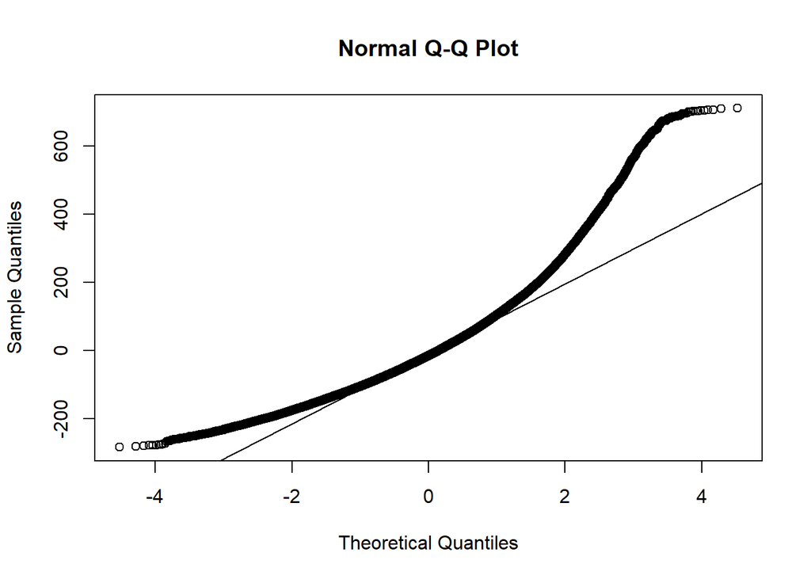

```r
qqnorm(lm$residuals)
qqline(lm$residuals)
```

##### 7.1.3.3 Are residuals homoskedastic?

1. First model which is not considering heteroskedasticity

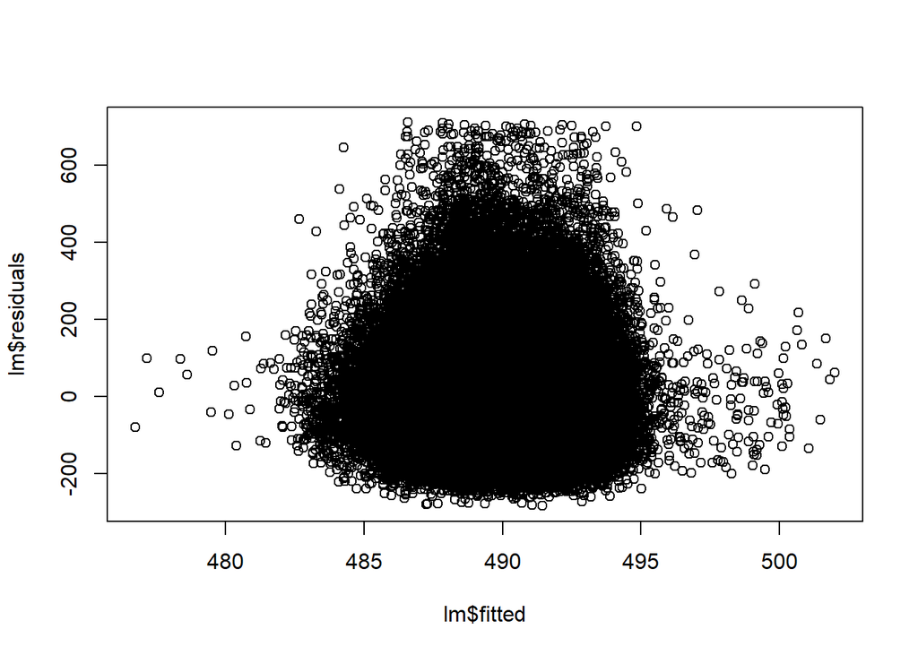

```r
plot(lm$residuals~lm$fitted)
```

```r
library(lmtest)
# Breush Pagan test H0 : homoskedasticity against H1 : heteroskedasticity

bptest(lm)
```

```
##
##  studentized Breusch-Pagan test
##
## data:  lm
## BP = 38.764, df = 40, p-value = 0.5258
```

In case of heteroskedasticity, we have to use a robust standard error estimator. Otherwise, all our t-tests will be wrong.

2. Second model taking into account heteroskedasticity

We calculate the robust covariance matrix

```r
library(sandwich)
vcov_y0 <- vcovHC(lm, type = "HC1")
coeftest(lm, vcov. = vcov_y0)
```

```
##
## t test of coefficients:
##
##                                               Estimate  Std. Error t value
## (Intercept)                                 6.1714e+02  2.8967e+02  2.1305
## alert.reason.category2                     -7.9673e-01  2.0957e+00 -0.3802
## alert.reason.category3                      1.1366e+00  1.2590e+00  0.9027
## alert.reason.category4                     -2.1892e+00  3.7589e+00 -0.5824
## alert.reason.category5                      6.2079e-01  5.5720e+00  0.1114
## alert.reason.category6                     -2.0146e+00  2.2487e+00 -0.8959
## alert.reason.category7                      1.5063e+00  4.7999e+00  0.3138
## alert.reason.category8                      8.9611e+00  1.0339e+01  0.8668
## alert.reason.category9                      5.4524e-01  1.8597e+00  0.2932
## longitude.intervention                      7.1714e+00  3.3262e+00  2.1560
## latitude.intervention                      -2.9227e+00  5.9226e+00 -0.4935
## delta.status.preceding.selection.selection -5.7035e-06  6.7181e-06 -0.8490
## departed.from.its.rescue.center1           -9.3094e-01  1.9243e+00 -0.4838
## OSRM.estimated.distance                     1.1055e-03  1.1907e-03  0.9284
## OSRM.estimated.duration                    -1.0731e-02  1.1443e-02 -0.9378
## OSRM.estimated.speed                       -5.1160e-02  8.7194e-02 -0.5867
## hours01                                     9.4205e-01  2.1927e+00  0.4296
## hours02                                     8.8507e-01  2.3120e+00  0.3828
## hours03                                     3.8307e+00  2.4310e+00  1.5758
## hours04                                    -1.1608e+00  2.4466e+00 -0.4744
## hours05                                    -7.2998e-01  2.4932e+00 -0.2928
## hours06                                     5.9753e-01  2.4485e+00  0.2440
## hours07                                     2.1870e+00  2.2585e+00  0.9683
## hours08                                     3.4605e-01  2.0688e+00  0.1673
## hours09                                     2.9591e+00  1.9992e+00  1.4801
## hours10                                     2.1445e+00  1.9490e+00  1.1003
## hours11                                     2.9369e-01  1.9360e+00  0.1517
## hours12                                    -2.0467e-01  1.9114e+00 -0.1071
## hours13                                     2.2746e+00  1.9086e+00  1.1918
## hours14                                     2.2834e-01  1.9327e+00  0.1181
## hours15                                     4.7783e-01  1.9317e+00  0.2474
## hours16                                    -4.1945e-01  1.9305e+00 -0.2173
## hours17                                     5.4760e-01  1.9404e+00  0.2822
## hours18                                     1.9762e+00  1.9289e+00  1.0245
## hours19                                    -1.9569e+00  1.9094e+00 -1.0249
## hours20                                     7.9876e-01  1.8976e+00  0.4209
```

[output cut: 34 more lines]

```
## hours13                                     0.23334
## hours14                                     0.90595
## hours15                                     0.80463
## hours16                                     0.82800
## hours17                                     0.77779
## hours18                                     0.30559
## hours19                                     0.30542
## hours20                                     0.67380
## hours21                                     0.02485 *
## hours22                                     0.10915
## hours23                                     0.10221
## emergency.vehicle.type.regroup              0.48306
## rescue.center.regroup                       0.97548
## ---
## Signif. codes:  0 '***' 0.001 '**' 0.01 '*' 0.05 '.' 0.1 ' ' 1
```

##### 7.2.3.4 Are the residuals correlated ?

There are several tests for autocorrelation Durbin-Watson test is one of the most often used

H0 : Residuals are non autocorrelated H1 : Residuals are autocorrelated

1. First model which is not considering heteroskedasticity

We can’t use the Durbin-Waston test since the size of our linear regression

2. Second model taking into account heteroskedasticity

```r
library(sandwich)

#Calculate the robust covariance matrix

vcov_y0_2 <- NeweyWest(lm)

coeftest(lm, vcov. = vcov_y0_2)
```

```
##
## t test of coefficients:
##
##                                               Estimate  Std. Error t value
## (Intercept)                                 6.1714e+02  2.8887e+02  2.1364
## alert.reason.category2                     -7.9673e-01  2.0858e+00 -0.3820
## alert.reason.category3                      1.1366e+00  1.2538e+00  0.9065
## alert.reason.category4                     -2.1892e+00  3.7547e+00 -0.5830
## alert.reason.category5                      6.2079e-01  5.5613e+00  0.1116
## alert.reason.category6                     -2.0146e+00  2.2445e+00 -0.8976
## alert.reason.category7                      1.5063e+00  4.7734e+00  0.3156
## alert.reason.category8                      8.9611e+00  1.0342e+01  0.8664
## alert.reason.category9                      5.4524e-01  1.8658e+00  0.2922
## longitude.intervention                      7.1714e+00  3.3420e+00  2.1458
## latitude.intervention                      -2.9227e+00  5.9070e+00 -0.4948
## delta.status.preceding.selection.selection -5.7035e-06  6.7209e-06 -0.8486
## departed.from.its.rescue.center1           -9.3094e-01  1.9204e+00 -0.4848
## OSRM.estimated.distance                     1.1055e-03  1.2016e-03  0.9200
## OSRM.estimated.duration                    -1.0731e-02  1.1560e-02 -0.9283
## OSRM.estimated.speed                       -5.1160e-02  8.7546e-02 -0.5844
## hours01                                     9.4205e-01  2.1820e+00  0.4317
## hours02                                     8.8507e-01  2.3001e+00  0.3848
## hours03                                     3.8307e+00  2.4254e+00  1.5794
## hours04                                    -1.1608e+00  2.4411e+00 -0.4755
## hours05                                    -7.2998e-01  2.4871e+00 -0.2935
## hours06                                     5.9753e-01  2.4638e+00  0.2425
## hours07                                     2.1870e+00  2.2628e+00  0.9665
## hours08                                     3.4605e-01  2.0638e+00  0.1677
## hours09                                     2.9591e+00  1.9915e+00  1.4859
## hours10                                     2.1445e+00  1.9643e+00  1.0917
## hours11                                     2.9369e-01  1.9371e+00  0.1516
## hours12                                    -2.0467e-01  1.9029e+00 -0.1076
## hours13                                     2.2746e+00  1.8970e+00  1.1991
## hours14                                     2.2834e-01  1.9483e+00  0.1172
## hours15                                     4.7783e-01  1.9305e+00  0.2475
## hours16                                    -4.1945e-01  1.9318e+00 -0.2171
## hours17                                     5.4760e-01  1.9460e+00  0.2814
## hours18                                     1.9762e+00  1.9253e+00  1.0265
## hours19                                    -1.9569e+00  1.9169e+00 -1.0209
## hours20                                     7.9876e-01  1.8994e+00  0.4205
```

[output cut: 34 more lines]

```
## hours13                                     0.23051
## hours14                                     0.90670
## hours15                                     0.80452
## hours16                                     0.82811
## hours17                                     0.77841
## hours18                                     0.30468
## hours19                                     0.30731
## hours20                                     0.67410
## hours21                                     0.02471 *
## hours22                                     0.10569
## hours23                                     0.10125
## emergency.vehicle.type.regroup              0.48160
## rescue.center.regroup                       0.97539
## ---
## Signif. codes:  0 '***' 0.001 '**' 0.01 '*' 0.05 '.' 0.1 ' ' 1
```

#### 7.1.4 Y0 : Prediction

```r
pred_reg_y0 <- predict(lm,testset0.regroup)
```

```r
pred_reg_y0 %>% head
```

```
##        1        2        3        4        5        6
## 488.2622 488.5124 488.1076 488.4798 489.5142 489.0530
```

```r
testset$delta.selection.departure %>% head
```

```
## [1] 488 314 641 387 585 629
```

Compute R2

```r
postResample(pred = pred_reg_y0, obs = testset0.regroup$delta.selection.departure)
```

```
##         RMSE     Rsquared          MAE
## 1.135184e+02 1.251241e-05 8.683858e+01
```

Pred for x_0

```r
pred_reg_final_y0 <- predict(lm,x_test0.regroup)
```

### 7.2 Y1

Remove id variable

```r
trainset1.regroup<-trainset1.regroup[,-c("emergency.vehicle.selection")]
trainset1.regroup$delta.departure.presentation<-trainset$delta.departure.presentation
```

```r
testset1.regroup<-testset1.regroup[,-c("emergency.vehicle.selection")]
testset1.regroup$delta.departure.presentation<-testset$delta.departure.presentation
```

Same x_test

```r
x_test1.regroup<-x_test1.regroup[,-c("emergency.vehicle.selection")]
```

```r
#Linear Regression,

options(max.print = 10000)

lm1 <- lm(delta.departure.presentation ~.,data = trainset1.regroup)


summary(lm1)
```

```
##
## Call:
## lm(formula = delta.departure.presentation ~ ., data = trainset1.regroup)
##
## Residuals:
##     Min      1Q  Median      3Q     Max
## -36.928 -17.728  -9.982  10.844 208.262
##
## Coefficients:
##                                              Estimate Std. Error t value
## (Intercept)                                 2.775e+02  6.303e+01   4.403
## n2                                          7.611e-01  3.135e-01   2.428
## n3                                          8.016e-01  5.709e-01   1.404
## n4                                          4.607e-01  1.063e+00   0.433
## n5                                          9.024e-01  1.589e+00   0.568
## n6                                         -1.035e+00  1.785e+00  -0.580
## n7                                          3.380e+00  2.052e+00   1.648
## n8                                          5.126e+00  6.889e+00   0.744
## n10                                        -1.452e+01  9.376e+00  -1.549
## n11                                        -5.937e+00  5.849e+00  -1.015
## n12                                        -9.540e+00  5.852e+00  -1.630
## n14                                         1.302e+01  7.481e+00   1.741
## alert.reason.category2                     -1.290e-01  4.869e-01  -0.265
## alert.reason.category3                      8.198e-02  3.049e-01   0.269
## alert.reason.category4                      2.880e-01  8.564e-01   0.336
## alert.reason.category5                     -9.230e-01  1.187e+00  -0.777
## alert.reason.category6                     -4.753e-01  5.066e-01  -0.938
## alert.reason.category7                     -8.003e-01  1.087e+00  -0.736
## alert.reason.category8                     -3.313e-01  2.032e+00  -0.163
## alert.reason.category9                      4.986e-01  4.343e-01   1.148
## intervention.on.public.roads1               1.328e-01  1.950e-01   0.681
## floor-1                                    -7.772e-01  1.043e+00  -0.745
## floor0                                     -6.512e-01  9.474e-01  -0.687
## floor1                                     -4.249e-01  9.683e-01  -0.439
## floor2                                     -6.786e-01  9.737e-01  -0.697
## floor3                                     -4.789e-01  9.789e-01  -0.489
## floor4                                     -7.886e-01  9.871e-01  -0.799
## floor5                                     -6.366e-01  1.004e+00  -0.634
## floor6                                     -8.258e-01  1.029e+00  -0.803
## floor7                                      1.841e-01  1.085e+00   0.170
```

[output cut: 138 more lines]

```
## hours18                                      0.8634
## hours19                                      0.7092
## hours20                                      0.6947
## hours21                                      0.3103
## hours22                                      0.5604
## hours23                                      0.4653
## emergency.vehicle.type.regroup               0.9230
## rescue.center.regroup                        0.0510 .
## location.of.the.event.regroup                0.3391
## ---
## Signif. codes:  0 '***' 0.001 '**' 0.01 '*' 0.05 '.' 0.1 ' ' 1
##
## Residual standard error: 24.77 on 164884 degrees of freedom
## Multiple R-squared:  0.0005977,  Adjusted R-squared:  7.032e-05
## F-statistic: 1.133 on 87 and 164884 DF,  p-value: 0.1859
```

```r
library(sandwich)
library(car)

vif(lm1)
```

```
##                                                 GVIF Df GVIF^(1/(2*Df))
## n                                           1.702611 11        1.024484
## alert.reason.category                       2.079311  8        1.046815
## intervention.on.public.roads                1.341905  1        1.158406
## floor                                       1.416990 19        1.009214
## longitude.intervention                      1.085996  1        1.042111
## latitude.intervention                       1.072789  1        1.035755
## delta.status.preceding.selection.selection  1.203363  1        1.096979
## OSRM.estimated.distance                    32.052370  1        5.661481
## OSRM.estimated.duration                    22.988328  1        4.794614
## OSRM.estimated.speed                        4.533710  1        2.129251
## month                                       1.030125 10        1.001485
## weekdays                                    1.022630  6        1.001867
## hours                                       1.079216 23        1.001659
## emergency.vehicle.type.regroup              1.448947  1        1.203722
## rescue.center.regroup                       1.055669  1        1.027458
## location.of.the.event.regroup               1.519499  1        1.232680
```

```r
#variables qualitatives
```

Except for OSRM data, no high correlated coefficient. We decide to keep them as they are important for our model.

#### 7.2.3 Y1 : Residuals analysis

Study the residuals of the selected model What we’ve done is not enough to validate the model. We need to study the residuals if hypothesis are not validated (see course.), the test of the coefficient are false Study the residuals of the selected model

##### 7.2.3.1 Is residuals means 0?

```r
#mean of residuals
summary(lm1$residuals)
```

```
##    Min. 1st Qu.  Median    Mean 3rd Qu.    Max.
## -36.928 -17.728  -9.982   0.000  10.844 208.262
```

Yes it is !

##### 7.2.3.2 Are residuals normally distributed?

```r
library(tseries)

jarque.bera.test(lm1$residuals)
```

```
##
##  Jarque Bera Test
##
## data:  lm1$residuals
## X-squared = 54482, df = 2, p-value < 2.2e-16
```

```r
#install.packages("nortest")
library(nortest)
ad.test(lm1$residuals)
```

```
##
##  Anderson-Darling normality test
##
## data:  lm1$residuals
## A = 9990.2, p-value < 2.2e-16
```

No normality because p-value is << 5%. Here, residuals are not normally distributed. NB : non normality could appear because of outliers.

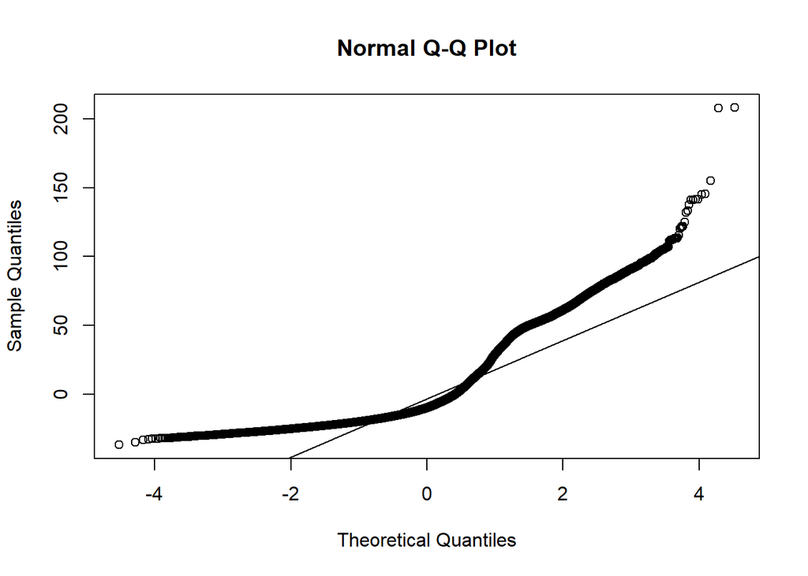

```r
qqnorm(lm1$residuals)
qqline(lm1$residuals)
```

##### 7.2.3.3 Are residuals homoskedastic?

1. First model which is not considering heteroskedasticity

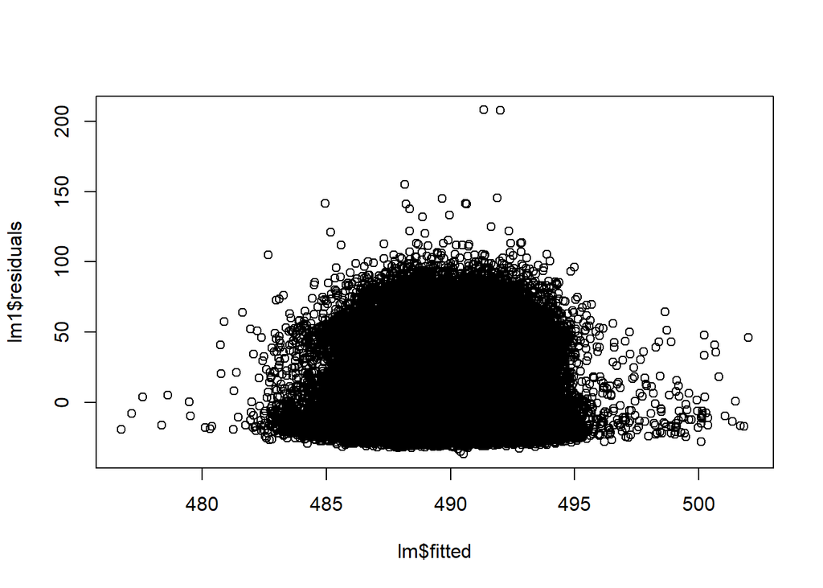

```r
plot(lm1$residuals~lm$fitted)
```

```r
library(lmtest)

# Breush Pagan test H0 : homoskedasticity against H1 : heteroskedasticity

bptest(lm1)
```

```
##
##  studentized Breusch-Pagan test
##
## data:  lm1
## BP = 103.7, df = 87, p-value = 0.107
```

In case of heteroskedasticity, we have to use a robust standard error estimator. Otherwise, all our t-tests will be wrong.

2. Second model taking into account heteroskedasticity

```r
library(sandwich)

#Calculate the robust covariance matrix

vcov_y1 <- vcovHC(lm1, type = "HC1")

coeftest(lm, vcov. = vcov_y1)
```

```
##
## t test of coefficients:
##
##                                               Estimate  Std. Error t value
## (Intercept)                                 6.1714e+02  6.3088e+01  9.7823
## alert.reason.category2                     -7.9673e-01  4.8577e-01 -1.6401
## alert.reason.category3                      1.1366e+00  3.0347e-01  3.7453
## alert.reason.category4                     -2.1892e+00  8.3985e-01 -2.6066
## alert.reason.category5                      6.2079e-01  1.1173e+00  0.5556
## alert.reason.category6                     -2.0146e+00  5.0382e-01 -3.9987
## alert.reason.category7                      1.5063e+00  1.0767e+00  1.3990
## alert.reason.category8                      8.9611e+00  1.8017e+00  4.9736
## alert.reason.category9                      5.4524e-01  4.3992e-01  1.2394
## longitude.intervention                      7.1714e+00  7.3499e-01  9.7571
## latitude.intervention                      -2.9227e+00  1.2902e+00 -2.2653
## delta.status.preceding.selection.selection -5.7035e-06  1.5522e-06 -3.6744
## OSRM.estimated.distance                     1.1055e-03  2.5717e-04  4.2987
## OSRM.estimated.duration                    -1.0731e-02  2.4710e-03 -4.3429
## OSRM.estimated.speed                       -5.1160e-02  1.8811e-02 -2.7197
## hours01                                     9.4205e-01  4.7348e-01  1.9896
## hours02                                     8.8507e-01  5.0480e-01  1.7533
## hours03                                     3.8307e+00  5.1011e-01  7.5096
## hours04                                    -1.1608e+00  5.2476e-01 -2.2120
## hours05                                    -7.2998e-01  5.3874e-01 -1.3550
## hours06                                     5.9753e-01  5.2994e-01  1.1275
## hours07                                     2.1870e+00  4.9093e-01  4.4549
## hours08                                     3.4605e-01  4.5822e-01  0.7552
## hours09                                     2.9591e+00  4.3486e-01  6.8047
## hours10                                     2.1445e+00  4.2382e-01  5.0599
## hours11                                     2.9369e-01  4.2004e-01  0.6992
## hours12                                    -2.0467e-01  4.1080e-01 -0.4982
## hours13                                     2.2746e+00  4.1651e-01  5.4612
## hours14                                     2.2834e-01  4.1932e-01  0.5446
## hours15                                     4.7783e-01  4.2612e-01  1.1213
## hours16                                    -4.1945e-01  4.1902e-01 -1.0010
## hours17                                     5.4760e-01  4.1925e-01  1.3062
## hours18                                     1.9762e+00  4.1746e-01  4.7339
## hours19                                    -1.9569e+00  4.1182e-01 -4.7518
## hours20                                     7.9876e-01  4.1235e-01  1.9371
## hours21                                     4.3818e+00  4.2255e-01 10.3697
```

[output cut: 32 more lines]

```
## hours13                                    4.735e-08 ***
## hours14                                    0.5860576
## hours15                                    0.2621465
## hours16                                    0.3168049
## hours17                                    0.1915032
## hours18                                    2.204e-06 ***
## hours19                                    2.018e-06 ***
## hours20                                    0.0527349 .
## hours21                                    < 2.2e-16 ***
## hours22                                    1.191e-13 ***
## hours23                                    3.237e-14 ***
## emergency.vehicle.type.regroup             0.0026104 **
## rescue.center.regroup                      0.9185171
## ---
## Signif. codes:  0 '***' 0.001 '**' 0.01 '*' 0.05 '.' 0.1 ' ' 1
```

##### 7.2.3.4 Are the residuals correlated ?

1. First model taking into account heteroskedasticity

```r
library(sandwich)

#Calculate the robust covariance matrix

vcov_y1_2 <- NeweyWest(lm1)

coeftest(lm1, vcov. = vcov_y1_2)
```

```
##
## t test of coefficients:
##
##                                               Estimate  Std. Error t value
## (Intercept)                                 2.7752e+02  6.3070e+01  4.4002
## n2                                          7.6113e-01  3.1706e-01  2.4006
## n3                                          8.0162e-01  5.9558e-01  1.3460
## n4                                          4.6066e-01  1.0507e+00  0.4384
## n5                                          9.0237e-01  1.5749e+00  0.5730
## n6                                         -1.0353e+00  1.7888e+00 -0.5788
## n7                                          3.3804e+00  2.1244e+00  1.5913
## n8                                          5.1255e+00  7.2689e+00  0.7051
## n10                                        -1.4523e+01  6.5043e+00 -2.2329
## n11                                        -5.9374e+00  6.0002e+00 -0.9895
## n12                                        -9.5402e+00  3.0508e+00 -3.1271
## n14                                         1.3021e+01  9.6443e+00  1.3501
## alert.reason.category2                     -1.2897e-01  4.8421e-01 -0.2664
## alert.reason.category3                      8.1983e-02  3.0311e-01  0.2705
## alert.reason.category4                      2.8803e-01  8.4299e-01  0.3417
## alert.reason.category5                     -9.2305e-01  1.1293e+00 -0.8174
## alert.reason.category6                     -4.7529e-01  5.0806e-01 -0.9355
## alert.reason.category7                     -8.0026e-01  1.0733e+00 -0.7456
## alert.reason.category8                     -3.3133e-01  1.8028e+00 -0.1838
## alert.reason.category9                      4.9859e-01  4.4015e-01  1.1328
## intervention.on.public.roads1               1.3279e-01  1.9418e-01  0.6838
## floor-1                                    -7.7723e-01  1.0617e+00 -0.7320
## floor0                                     -6.5124e-01  9.6877e-01 -0.6722
## floor1                                     -4.2490e-01  9.8479e-01 -0.4315
## floor2                                     -6.7863e-01  9.9243e-01 -0.6838
## floor3                                     -4.7888e-01  1.0004e+00 -0.4787
## floor4                                     -7.8855e-01  1.0080e+00 -0.7823
## floor5                                     -6.3661e-01  1.0232e+00 -0.6222
## floor6                                     -8.2583e-01  1.0423e+00 -0.7923
## floor7                                      1.8412e-01  1.1122e+00  0.1655
## floor8                                     -4.0883e-01  1.1933e+00 -0.3426
## floor9                                      4.3712e-01  1.2742e+00  0.3431
## floor10                                     1.2486e+00  1.4122e+00  0.8841
## floor11                                    -4.1495e-01  1.4960e+00 -0.2774
## floor12                                    -6.0226e-01  1.6746e+00 -0.3596
## floor13                                    -1.8448e+00  1.7101e+00 -1.0788
```

[output cut: 128 more lines]

```
## hours14                                     0.469017
## hours15                                     0.153321
## hours16                                     0.277076
## hours17                                     0.712278
## hours18                                     0.861778
## hours19                                     0.706621
## hours20                                     0.691083
## hours21                                     0.306915
## hours22                                     0.557964
## hours23                                     0.463048
## emergency.vehicle.type.regroup              0.924310
## rescue.center.regroup                       0.048455 *
## location.of.the.event.regroup               0.340099
## ---
## Signif. codes:  0 '***' 0.001 '**' 0.01 '*' 0.05 '.' 0.1 ' ' 1
```

#### 7.2.4 Y1 : Prediction

```r
pred_reg_y1 <- predict(lm1,testset1.regroup)
```

```r
pred_reg_y1 %>% head
```

```
##        1        2        3        4        5        6
## 137.6010 138.1864 137.5269 137.4161 137.8119 137.7804
```

```r
testset$delta.departure.presentation %>% head
```

```
## [1] 119 130 124 134 191 133
```

Compute MSE

```r
postResample(pred = pred_reg_y1, obs = testset1.regroup$delta.departure.presentation)
```

```
##         RMSE     Rsquared          MAE
## 2.475217e+01 2.443775e-07 1.966788e+01
```

##### Pred for x_1

```r
testset1.regroup %>% str
```

```
## Classes 'data.table' and 'data.frame':   41243 obs. of  17 variables:
##  $ n                                         : Factor w/ 12 levels "1","2","3","4",..: 1 1 1 1 1 1 1 1 1 1 ...
##  $ alert.reason.category                     : Factor w/ 9 levels "1","2","3","4",..: 3 3 3 3 3 3 3 3 3 3 ...
##  $ intervention.on.public.roads              : Factor w/ 2 levels "0","1": 2 1 1 1 1 1 1 1 1 1 ...
##  $ floor                                     : Factor w/ 20 levels "-2","-1","0",..: 3 4 3 5 3 3 3 3 3 3 ...
##  $ longitude.intervention                    : num  2.3 2.2 2.28 2.29 2.32 ...
##  $ latitude.intervention                     : num  48.9 48.9 48.9 48.9 48.9 ...
##  $ delta.status.preceding.selection.selection: int  606 4693 968 1415 1204 1379 2254 634 3013 2793 ...
##  $ OSRM.estimated.distance                   : num  1812 2586 2114 431 839 ...
##  $ OSRM.estimated.duration                   : num  197.8 280 243.7 79.8 111 ...
##  $ OSRM.estimated.speed                      : num  33 33.2 31.2 19.5 27.2 ...
##  $ month                                     : Factor w/ 11 levels "1","2","3","4",..: 1 1 1 1 1 1 1 1 1 1 ...
##  $ weekdays                                  : Factor w/ 7 levels "dimanche","jeudi",..: 3 3 3 3 3 3 3 3 3 3 ...
##  $ hours                                     : Factor w/ 24 levels "00","01","02",..: 1 2 1 1 2 2 2 2 3 3 ...
##  $ emergency.vehicle.type.regroup            : num  1 1 1 1 1 1 1 1 1 1 ...
##  $ rescue.center.regroup                     : num  0 0 0 0 0 0 0 0 1 0 ...
##  $ location.of.the.event.regroup             : num  0 1 0 1 0 0 0 0 1 1 ...
##  $ delta.departure.presentation              : num  119 130 124 134 191 133 192 125 129 160 ...
##  - attr(*, ".internal.selfref")=<externalptr>
```

```r
x_test1.regroup %>% str
```

```
## Classes 'data.table' and 'data.frame':   108033 obs. of  16 variables:
##  $ n                                         : Factor w/ 13 levels "1","2","3","4",..: 1 1 1 1 1 1 1 1 1 1 ...
##  $ alert.reason.category                     : Factor w/ 9 levels "1","2","3","4",..: 1 1 3 3 1 3 1 3 3 3 ...
##  $ intervention.on.public.roads              : Factor w/ 2 levels "0","1": 1 1 1 1 2 1 2 1 1 1 ...
##  $ floor                                     : Factor w/ 20 levels "-2","-1","0",..: 8 6 7 3 3 3 3 4 3 8 ...
##  $ longitude.intervention                    : num  2.34 2.28 2.28 2.34 2.41 ...
##  $ latitude.intervention                     : num  48.9 48.9 48.9 48.9 48.9 ...
##  $ delta.status.preceding.selection.selection: int  2636 16243 597 1834 1341 2197 16 1312 263 437 ...
##  $ OSRM.estimated.distance                   : num  1283 2347 1078 1791 1451 ...
##  $ OSRM.estimated.duration                   : num  214 218 120 250 199 ...
##  $ OSRM.estimated.speed                      : num  21.6 38.8 32.4 25.7 26.2 ...
##  $ month                                     : Factor w/ 11 levels "1","2","3","4",..: 1 1 1 1 1 1 1 1 1 1 ...
##  $ weekdays                                  : Factor w/ 7 levels "dimanche","jeudi",..: 3 3 3 3 3 3 3 3 3 3 ...
##  $ hours                                     : Factor w/ 24 levels "00","01","02",..: 12 10 1 1 1 2 2 2 2 2 ...
##  $ emergency.vehicle.type.regroup            : num  1 0 1 1 1 1 1 1 1 1 ...
##  $ rescue.center.regroup                     : num  0 0 0 0 0 1 1 0 0 0 ...
##  $ location.of.the.event.regroup             : num  1 0 1 0 0 0 0 0 0 1 ...
##  - attr(*, ".internal.selfref")=<externalptr>
```

```r
#pred_reg_final_y1 <- predict(lm1,x_test1.regroup)
```

New levels in x_test

```r
testset1.regroup$n %>% levels
```

```
##  [1] "1"  "2"  "3"  "4"  "5"  "6"  "7"  "8"  "10" "11" "12" "14"
```

```r
x_test1.regroup$n %>% levels
```

```
##  [1] "1"  "2"  "3"  "4"  "5"  "6"  "7"  "8"  "9"  "10" "11" "12" "13"
```

Re_train model without n-levels

```r
#Linear Regression,

options(max.print = 10000)

lm1 <- lm(delta.departure.presentation ~.,data = trainset1.regroup[,-c("n")])


summary(lm1)
```

```
##
## Call:
## lm(formula = delta.departure.presentation ~ ., data = trainset1.regroup[,
##     -c("n")])
##
## Residuals:
##     Min      1Q  Median      3Q     Max
## -34.923 -17.726  -9.987  10.867 208.616
##
## Coefficients:
##                                              Estimate Std. Error t value
## (Intercept)                                 2.778e+02  6.300e+01   4.410
## alert.reason.category2                     -4.084e-01  4.692e-01  -0.870
## alert.reason.category3                     -2.288e-01  2.701e-01  -0.847
## alert.reason.category4                     -1.640e-02  8.444e-01  -0.019
## alert.reason.category5                     -1.240e+00  1.178e+00  -1.052
## alert.reason.category6                     -6.443e-01  4.933e-01  -1.306
## alert.reason.category7                     -1.036e+00  1.081e+00  -0.959
## alert.reason.category8                     -2.919e-01  2.030e+00  -0.144
## alert.reason.category9                      2.074e-01  4.123e-01   0.503
## intervention.on.public.roads1               1.142e-01  1.947e-01   0.586
## floor-1                                    -7.962e-01  1.043e+00  -0.763
## floor0                                     -7.062e-01  9.458e-01  -0.747
## floor1                                     -4.657e-01  9.670e-01  -0.482
## floor2                                     -7.150e-01  9.722e-01  -0.735
## floor3                                     -5.154e-01  9.775e-01  -0.527
## floor4                                     -8.305e-01  9.857e-01  -0.843
## floor5                                     -6.662e-01  1.002e+00  -0.665
## floor6                                     -8.568e-01  1.027e+00  -0.834
## floor7                                      1.523e-01  1.083e+00   0.141
## floor8                                     -4.177e-01  1.161e+00  -0.360
## floor9                                      3.952e-01  1.259e+00   0.314
## floor10                                     1.207e+00  1.365e+00   0.884
## floor11                                    -4.500e-01  1.491e+00  -0.302
## floor12                                    -6.642e-01  1.670e+00  -0.398
## floor13                                    -1.880e+00  1.816e+00  -1.035
## floor14                                     2.064e+00  2.022e+00   1.021
## floor15                                     4.653e-01  2.264e+00   0.206
## floor16                                     2.535e+00  2.607e+00   0.973
## floor17                                    -2.318e-02  1.667e+00  -0.014
```

[output cut: 117 more lines]

```
## hours18                                      0.8636
## hours19                                      0.7129
## hours20                                      0.6912
## hours21                                      0.3056
## hours22                                      0.5707
## hours23                                      0.4637
## emergency.vehicle.type.regroup               0.4955
## rescue.center.regroup                        0.0465 *
## location.of.the.event.regroup                0.3207
## ---
## Signif. codes:  0 '***' 0.001 '**' 0.01 '*' 0.05 '.' 0.1 ' ' 1
##
## Residual standard error: 24.77 on 164895 degrees of freedom
## Multiple R-squared:  0.0004787,  Adjusted R-squared:  1.799e-05
## F-statistic: 1.039 on 76 and 164895 DF,  p-value: 0.3853
```

```r
pred_reg_final_y1 <- predict(lm1,x_test1.regroup[,-c("n")])
```

### 7.4 Ys : Compute global

```r
pred_reg_ys=pred_reg_y0+pred_reg_y1
pred_reg=data.frame(pred_reg_y0,pred_reg_y1,pred_reg_ys)

pred_reg %>% head
```

```
##   pred_reg_y0 pred_reg_y1 pred_reg_ys
## 1    488.2622    137.6010    625.8632
## 2    488.5124    138.1864    626.6987
## 3    488.1076    137.5269    625.6345
## 4    488.4798    137.4161    625.8959
## 5    489.5142    137.8119    627.3260
## 6    489.0530    137.7804    626.8334
```

```r
testset$delta.selection.presentation %>% head
```

```
## [1] 369 184 516 252 393 495
```

```r
postResample(pred = pred_reg_ys, obs = testset$delta.departure.presentation)
```

```
##         RMSE     Rsquared          MAE
## 4.905755e+02 1.631441e-10 4.899463e+02
```

## 8. Actual predict : Compute Global for x_test

```r
pred_reg_final_ys=pred_reg_final_y0+pred_reg_final_y1
pred_final=data.frame(pred_reg_final_y0,pred_reg_final_y1,pred_reg_final_ys)
pred_final %>% head
```

```
##   pred_reg_final_y0 pred_reg_final_y1 pred_reg_final_ys
## 1          488.4207          137.9006          626.3213
## 2          490.8036          138.0961          628.8998
## 3          488.1664          137.4158          625.5822
## 4          488.3119          137.4880          625.7998
## 5          487.9201          137.9851          625.9052
## 6          490.4115          137.3935          627.8051
```

```r
pred_final$id<-x_test$emergency.vehicle.selection
```

Change order

```r
pred_final <- pred_final[, c(4, 1, 2, 3)]
```

Convert into integer

```r
pred_final$pred_reg_final_y0=pred_final$pred_reg_final_y0 %>% as.integer()
pred_final$pred_reg_final_y1=pred_final$pred_reg_final_y1 %>% as.integer()
pred_final$pred_reg_final_ys=pred_final$pred_reg_final_ys %>% as.integer
```

Retrieve Order from challange

```r
#order_x_test<-read.csv("x_test.csv")
#order_x_test<-data.frame(order_x_test$emergency.vehicle.selection)

#order_x_test %>% setDT
#order_x_test %>% head
#str(order_x_test)

#y_final<-merge(order_x_test,pred_final, by.x = 'order_x_test.emergency.vehicle.selection', by.y = 'emergency-vehicle-selection', all = FALSE,sort=FALSE)
```

```r
#y_final %>% str
```

```r
#sum(is.na(y_final))
#which(is.na(y_final))
#y_final[is.na(y_final)] <- 0
```

```r
#fwrite(y_final, "y_test.csv",sep=",")
```

## Acknowledgements and references

The following is a list of helpful contributor.

- Professor Nadine Galy- Econometrics and Statitical Models [U1 -MSc AI and BA- TBS] - 2020
- Github https://github.com/quachn/X_PFB
- Medium https://medium.com/crim/predicting-the-response-times-of-firefighters-using-data-science-da79f6965f93
- Kaggle https://www.kaggle.com/headsortails/nyc-taxi-eda-update-the-fast-the-curious
- Stack Overflow community

Thank you for reading !